# Patient heterogeneity based on inflammation genes

Xiting Yan

10/02/2019

In this note, we use WGCNA to identify gene modules within the inflammation genes (IFG related genes). Then we cluster patients based on these gene modules and try to identify clinical traits associated with the clusters. This will define new phenotype based on inflammatory biomarkers (CRP).

# Interferon gamma signaling genes

We first did the analysis with inteferron gamma signaling genes downloaded from metacore.

## WGCNA on PBMC baseline adjusted data

We applied WGCNA to the expression levels of IFNgamma signaling genes to identify clusters of highly correlated genes.

### Data Loading (gene expression)

Load in and match the clinical data,fpkm matrix, and the sample mapping matrix.

```r
# These codes should be saved in /home/xy48/Rprogram/GRADS_PBMC/WGCNA/0_CleanDataLoad.R
home.dir<-"/home/yanxiting/driver_Grace"
#home.dir<-"/home/xy48"
data.dir<-file.path(home.dir,"scratch/GRADS/SARC_results/Results_summary_PBMC_hg38")
#fpkm.filepath<-file.path(home.dir,"scratch/GRADS/SARC_results/Results_summary_PBMC_hg38/baseline/data","TPM_baseline_276_clean_GRADSID.txt")
#fpkm.filepath<-file.path(home.dir,"scratch/GRADS/SARC_results/Results_summary_PBMC_hg38/baseline/data","TPM_baseline_276_clean_celldiffadjusted_withannot.txt")
fpkm.filepath<-file.path(home.dir,"scratch/GRADS/SARC_results/Results_summary_PBMC_hg38/baseline/data_adjusted2","TPM_baseline_276_clean_celldiffadjusted_withannot.txt")
masterkey.filepath<-file.path(home.dir,"scratch/GRADS/SARC_results/Data/GRADS Master Progress Key 6-13-16.xlsx")


# load in the list of GRADS IDs and KIT IDs from the master key file
mkey<-read.xls(masterkey.filepath,sheet=3,skip=2,header=T,check.names=F,stringsAsFactors = F)
mkey <- mkey[,1:5]

# load in the fpkm matrix
fpkm.matrix<-read.table(fpkm.filepath,sep="\t",header=T,check.names=F,as.is=TRUE,comment.char = "")
fpkm.matrix.anno<-fpkm.matrix[,1:5]
fpkm.matrix<-fpkm.matrix[,6:ncol(fpkm.matrix)]
data.matrix<-fpkm.matrix

# remove the GRADS IDs that do not have the FPKMs
temp.names<-colnames(fpkm.matrix)
matched.list <- mkey[mkey[,1]%in%temp.names,]
matched.list$`Phenotype/Genotype` <- as.factor(matched.list$`Phenotype/Genotype`)

# generate a matrix that match the columns of data.matrix
sample.matrix<-matched.list
rownames(sample.matrix)<-sample.matrix[,1]
sample.matrix<-sample.matrix[colnames(data.matrix),]
```

### Data Loading (clinical data and gene filtering)

Load in clinical matrix and extract data for the variables needed to correlate with the gene modules. Some of the clinical featuers were also re-coded.

```r
#-------------------------------------------------------------------------------------------------# /Rprogram/GRADS_PBMC/WGCNA/6_0_DataLoad.R
###################################################################
#  Load in both the gene expression and the clinical data
#  filter the genes based on given cv.threshold and match the gene expression data and the clinical data
#home.dir<-"/home/xy48"
home.dir<-"/home/yanxiting/driver_Grace"
cv.threshold<-0
#source(file.path(home.dir,"Rprogram/GRADS_PBMC/WGCNA/0_CleanDataLoad.R"))
output.dir<-file.path(home.dir,"scratch/GRADS/SARC_results/Results_summary_PBMC_hg38/baseline/WGCNA_IFNgamma")

if(file.exists(output.dir)==F){
dir.create(output.dir)
}

output.dir<-file.path(output.dir,paste("CV",cv.threshold,"_compare",sep=""))

if(file.exists(output.dir)==F){
dir.create(output.dir)
}

#=====================================================================================
#
#  Load in both the gene expression and the clinical data
#  Filter the genes based on CV and match the gene expression and the clinical data
#
#=====================================================================================
#clinic.filepath<-file.path(home.dir,"/home/yanxiting/Research/GRADS_SARC/Data/SARC_combine_clinical_data20170814.txt"

# the old.clinic.filepath had SCADDING and more features required for the WGCNA
# the clinic.filepath had updated features. So we load in both and merge them.
old.clinic.filepath<-file.path(home.dir,"scratch/GRADS/SARC_results/Results_summary_PBMC_hg38/data/clin_data_visit1_trunc_XY.csv")
clinic.filepath<-file.path(home.dir,"scratch/GRADS/SARC_results/Results_summary_PBMC_hg38/baseline/data/clin_data_visit1_XY.csv")


old.clinic.matrix=read.csv(old.clinic.filepath,check.names=F,stringsAsFactors=F)
clinic.matrix=read.csv(clinic.filepath,check.names=F,stringsAsFactors=F)

common.features<-intersect(colnames(old.clinic.matrix),colnames(clinic.matrix))
my.data<-clinic.matrix[,common.features]

old.features<-setdiff(colnames(old.clinic.matrix),colnames(clinic.matrix))
temp<-old.clinic.matrix[,old.features]
rownames(temp)<-old.clinic.matrix[,1]
temp<-temp[my.data[,1],]
my.data<-cbind(my.data,temp)

new.features<-setdiff(colnames(clinic.matrix),colnames(old.clinic.matrix))
temp<-clinic.matrix[,new.features]
rownames(temp)<-clinic.matrix[,1]
temp<-temp[my.data[,1],]
my.data<-cbind(my.data,temp)

clinic.matrix<-my.data
rownames(clinic.matrix)<-as.matrix(clinic.matrix)[,"GRADSID"] # GRADS ID
clinic.matrix<-clinic.matrix[sample.matrix[,1],]


# add the level of CRP
clinic.filepath<-file.path(home.dir,"scratch/GRADS/SARC_results/Data_PBMC/merge_visit_patient_v1.csv")
temp.matrix<-read.csv(clinic.filepath)
rownames(temp.matrix)<-temp.matrix[,1]
temp.matrix<-temp.matrix[rownames(clinic.matrix),]
clinic.matrix<-cbind(clinic.matrix,temp.matrix[,"crp"])
colnames(clinic.matrix)[ncol(clinic.matrix)]<-"CRP"

############### load in the list of IFN-gamma genes
data.filepath<-file.path(home.dir,"scratch/GRADS/SARC_results/Results_summary_PBMC_hg38/data/Interferon_gamma_signaling_metacore.xls")
gene.list<-read.xls(data.filepath,check.names=F,skip=2,stringsAsFactors=F)
gene.list<-gene.list[gene.list$'Gene Symbol'!="",]
gene.list<-unique(gene.list$`Gene Symbol`)
length(gene.list)

data.matrix<-data.matrix[fpkm.matrix.anno[,1]%in%gene.list,]
fpkm.matrix.anno<-fpkm.matrix.anno[fpkm.matrix.anno[,1]%in%gene.list,]
rownames(data.matrix)<-paste0(fpkm.matrix.anno[,1],":",fpkm.matrix.anno[,"Chr"])
rownames(fpkm.matrix.anno)<-paste0(fpkm.matrix.anno[,1],":",fpkm.matrix.anno[,"Chr"])

##########for BAL samples
# only keep genes expressed (fpkm>0.01 in >10% samples) across all samples
bal.fpkm.matrix<-data.matrix
bal.clinic.matrix<-clinic.matrix

bal.fpkm.matrix<-bal.fpkm.matrix[apply(bal.fpkm.matrix>0.01,1,sum)>ncol(bal.fpkm.matrix)*0.1,]

########## filter genes using SD>0 and genes using CV>cv.threshold################
temp.sd<-apply(bal.fpkm.matrix,1,sd)
bal.fpkm.matrix <- bal.fpkm.matrix[temp.sd>0,]

#temp.mean<-apply(bal.fpkm.matrix,1,mean)
#temp.sd<-apply(bal.fpkm.matrix,1,sd)
#temp.cv<-temp.sd/temp.mean
#my.data.matrix<-bal.fpkm.matrix[temp.cv>=cv.threshold,]

my.data.matrix<-bal.fpkm.matrix

library(WGCNA)
collectGarbage()

datExpr<-t(my.data.matrix)

# remove certain columns in the clinical data
#datTraits<-bal.clinic.matrix[,-c(1,6,8:41)]
datTraits<-bal.clinic.matrix[,-1]

# change PHENGRP and SCADDING into numbers
temp.vect<-datTraits[,"SCADDING"]
temp.num<-as.numeric(factor(temp.vect,levels=c("0","I","II","III","IV","N/A")))
temp.num[temp.num==6]<-NA
datTraits[,"SCADDING"]<-temp.num

# recode PHENGRP to treatment
temp.vect<-datTraits[,"PHENGRP"]
temp.num<-rep(0,length(temp.vect)) # untreated all samples
temp.num[temp.vect%in%c("Stage II-III, treated","Stage IV, treated")]<-1
temp.num[temp.vect%in%c("Multi-organ","Cardiac defining therapy")]<-NA

datTraits<-cbind(datTraits,temp.num)
colnames(datTraits)[ncol(datTraits)]<-"TREATMENT"

# add treatment for stage II-III
temp.vect<-datTraits[,"PHENGRP"]
temp.num<-rep(0,length(temp.vect))
temp.num[!temp.vect%in%c("Stage II-III, untreated","Stage II-III, treated" )]<-NA
temp.num[temp.vect%in%c("Stage II-III, treated")]<-1

datTraits<-cbind(datTraits,temp.num)
colnames(datTraits)[ncol(datTraits)]<-"TREATMENT_STAGEII-III"

# add treatment for stage IV
temp.vect<-datTraits[,"PHENGRP"]
temp.num<-rep(0,length(temp.vect))
temp.num[!temp.vect%in%c("Stage IV, treated","Stage IV, untreated")]<-NA
temp.num[temp.vect%in%c("Stage IV, treated")]<-1

datTraits<-cbind(datTraits,temp.num)
colnames(datTraits)[ncol(datTraits)]<-"TREATMENT_STAGEIV"

datTraits<-datTraits[,colnames(datTraits)!="PHENGRP"]


temp.names<-rownames(datTraits)
datTraits<-t(datTraits)

# change the names of the cell differentials
rownames(datTraits)[rownames(datTraits)=="p_lymph"]<-"LYMBALD"
rownames(datTraits)[rownames(datTraits)=="p_mono"]<-"MONOBALD"
rownames(datTraits)[rownames(datTraits)=="p_neut"]<-"NEUBALD"
rownames(datTraits)[rownames(datTraits)=="p_eos"]<-"EOSBALD"
rownames(datTraits)[rownames(datTraits)=="p_baso"]<-"BASBALD"


datTraits<-datTraits[c(
"AGE",
"GENDER",
"RACE",
"BDFEV1",
"FEV1PRED",
"BDFVC",
"FVCPRED",
"BDDLCO",
"PREDDLCO",
"ethor",
"cd4",
"cal",
"d25",
"d125",
"CRP",
"smoke",
"pk_yr",
"steroid_atv1",
"dmard_atv1",
"MONOBALD",
"EOSBALD",
"LYMBALD",
"NEUBALD",
"BASBALD",
"SCADDING"
),]

# set the negative values in the trait matrix into NAs
datTraits["LYMBALD",datTraits["LYMBALD",]==225.3]<-NA
datTraits[datTraits<0]<-NA

# set the cell differentials with 0 macrophages to be NAs
#datTraits[,(!is.na(datTraits["ALVBALD",])) & #datTraits["ALVBALD",]==0][c("ALVBALD","EOSBALD","LYMBALD","NEUBALD"),]<-NA
save.image(file.path(output.dir,"input_data.RData"))
```

### Outlier Removal

Generate the hierarhical clustering tree using the genes to identify potential outliers.

```r
#----------------------------------------------------------------------------------------------------------------------------------------------------
# /Rprogram/GRADS_PBMC/WGCNA/6_1_sampletree.R
#rdata.filepath<-file.path(output.dir,"input_data.RData")
library(WGCNA)

#rdata.filepath<-"/home/fas/kaminski/xy48/scratch/GRADS/SARC_results/Results_summary/WGCNA_BAL/PHGRP_filtering/CV0.4526_compare/input_data.RData"
#load(rdata.filepath)
sampleTree = hclust(dist(datExpr), method = "average");

# save the hierarchical tree before removing the outliers
output.filepath<-file.path(output.dir,"hclust_tree_allsamples.eps")
#sizeGrWindow(12,9)
#pdf(file = output.filepath);
postscript(output.filepath,width=10,height=10,paper="special")
par(cex = 0.6);
par(mar = c(0,4,2,0))
plot(sampleTree, main = "Sample clustering to detect outliers", sub="", xlab="", cex.lab = 1.5,
cex.axis = 1.5, cex.main = 2,cex=0.55)
#save plot
dev.off()

# output the heights on the tree so we can decide which heights to cut
output.filepath<-file.path(output.dir,"sampletree_height_list.txt")
cat(sampleTree$height,sep="\n",file=output.filepath,append=F)
```

### Decide Cutting Height

We need to go over the sampletree_height_list.txt and the hcluste_tree_allsamples.eps to decide where to cut on the hierarchical clustering tree. The first number in the files should be a number larger than the largest number in sampletree_height_list.txt to make sure we also run the program without removing any samples. Then each number in the file should be slightly smaller than the actual number in sampletree_height_list.txt to make sure we cut underneath the branch.

### Soft Power Picking

We need to generate the hclust_cut_heights.list.txt to provide the heights at which we would like to cut the hierarchical clustering tree. Name of this file cannot be changed and it has to be saved under the same folder where all WGCNA results are saved.

```r
#----------------------------------------------------------------------------------------------------------------------------------------------------
# /Rprogram/GRADS/BAL_final_hg38_20180726/WGCNA_unadjusted_ALL_filtering/6_2_sftpicking.R
####################################################
# load in all cut heights for a given cv.threshold, generate the soft power picking figures for each cut height
#rdata.filepath<-""
#cutheight.filepath<-""
#output.dir<-""
#rdata.filepath<-file.path(output.dir,"input_data.RData")
cutheight.filepath<-file.path(output.dir,"hclust_cut_heights_list.txt")
library(WGCNA)
#load(rdata.filepath)
enableWGCNAThreads(nThreads = 15)
# load in the height vector
#height.vect<-c(50000,48000,38080,37970,33640,25100,23700,19260,18260)
height.vect<-scan(cutheight.filepath)

sampleTree = hclust(dist(datExpr), method = "average")

outlier.list<-list()
outlier.list[[1]]<-character()
for(i in 1:length(height.vect)){
clust = cutreeStatic(sampleTree, cutHeight = height.vect[i], minSize = 10)
keepSamples = (clust==1)
outlier.list[[i]]<-setdiff(rownames(datExpr)[!keepSamples],unlist(outlier.list))
}

# output the height of cut, the number of outliers and the IDs of the outliers into one file
cmd.out<-cbind(height.vect,unlist(lapply(outlier.list,length)),unlist(lapply(outlier.list,paste,collapse=";")))
colnames(cmd.out)<-c("cut_height","outlier_number","outliers_ids")
output.filepath<-file.path(output.dir,"cutheight_2_sft.txt")
write.table(cmd.out,sep="\t",file=output.filepath,append=F,quote=F,row.names=F,col.names=T)


####################################################
# 6.1 for each given cut height, generate the soft power picking figures to pick soft power for each given cut height
# save the soft power picking figure into the same file for reviewing
pdf.filepath<-file.path(output.dir,"sft_picking.pdf")
pdf(pdf.filepath)
for(i in 1:length(outlier.list)){
#clust = cutreeStatic(sampleTree, cutHeight = height.vect[i], minSize = 10)
#keepSamples = (clust==1)
my.datExpr = datExpr[setdiff(rownames(datExpr),unlist(outlier.list[1:i])), ]


#rename the columns (remove all after _ in sample name)
SarcaleSamples = rownames(my.datExpr)
sampleRows =match(SarcaleSamples,rownames(sample.matrix));
sample.matrix.new=sample.matrix[sampleRows,]
traitRows = match(sample.matrix.new[,1],colnames(datTraits));
my.datTraits = datTraits[,traitRows];

nGenes = ncol(my.datExpr)
nSamples = nrow(my.datExpr)

powers = c(c(1:10), seq(from = 12, to=20, by=2))
# Call the network topology analysis function
sft = pickSoftThreshold(my.datExpr, powerVector = powers, verbose = 5)


# save the plot for picking the soft power
#output.filepath<-file.path(output.dir,"SoftPowerPick.eps")
#postscript(output.filepath,width=9,height=5,paper="special")
#sizeGrWindow(9, 5)
par(mfrow = c(1,2));
cex1 = 0.9;
# Scale-free topology fit index as a function of the soft-thresholding power
plot(sft$fitIndices[,1], -sign(sft$fitIndices[,3])*sft$fitIndices[,2],
xlab="Soft Threshold (power)",
ylab="Scale Free Topology Model Fit,signed R^2",type="n",
main = paste("Scale independence"));
text(sft$fitIndices[,1], -sign(sft$fitIndices[,3])*sft$fitIndices[,2],
labels=powers,cex=cex1,col="red");
# this line corresponds to using an R^2 cut-off of h
abline(h=0.90,col="red")
# Mean connectivity as a function of the soft-thresholding power
plot(sft$fitIndices[,1], sft$fitIndices[,5],
xlab="Soft Threshold (power)",ylab="Mean Connectivity", type="n",
main = paste("Mean connectivity\n","outlier.list[",i,"]",sep=""))
text(sft$fitIndices[,1], sft$fitIndices[,5], labels=powers,
cex=cex1,col="red")
#output.filepath<-file.path(output.dir,"SoftPowerPick.jpg")
#savePlot(output.filepath,type="jpeg")
#dev.off()

}
dev.off()

save.image(file.path(output.dir,"sft_picking.RData"))
```

We need to review the plots in sft_picking.pdf and generate a text file with each line describing the softpower we want to set for each cut height we picked before. This text file will be saved as sft_power_list.txt. The numbers will be in the same order as those plots in the sft_picking.pdf.

### Clustering

```r
#---------------------------------------------------------------------------------------------------------------------------------------------------
# /Users/yanxiting/MyVolumes/GRACE/Rprogram/GRADS/BAL_final_hg38_20180726/WGCNA_unadjusted_ALL_filtering/6_3_clustering.R
#output.dir<-file.path(home.dir,"scratch/GRADS/SARC_results/Results_summary_PBMC_hg38/baseline/WGCNA_celladjusted/CV0_compare")

#rdata.filepath<-file.path(output.dir,"sft_picking.RData")
sftpower.filepath<-file.path(output.dir,"sft_power_list.txt")
#load(rdata.filepath)

library(WGCNA)
enableWGCNAThreads(nThreads = 15)
library(gplots)


my.cor.dist<-function(x,method.name="spearman"){
# calculate the correlation between rows in x and return the correlation matrix as a distance matrix
y<-cor(t(x),method=method.name)
y[is.na(y)]<- -1.5
return(as.dist(1-y))
}


# for each element in outlier.list, pick power and put them in power.vect below for further analysis
#power.vect<-c(3,4,5,3,4,3,3,3,4)
power.vect<-scan(sftpower.filepath)
```

```r
net.list<-list()
# obtain the WGCNA results for each given set of outliers
for(i in 1:length(outlier.list)){
gc()
cat("i=",i,"\n",sep="")
#clust = cutreeStatic(sampleTree, cutHeight = height.vect[i], minSize = 10)
#keepSamples = (clust==1)
my.datExpr = datExpr[setdiff(rownames(datExpr),unlist(outlier.list[1:i])), ]

#rename the columns (remove all after _ in sample name)
SarcaleSamples = rownames(my.datExpr)
sampleRows =match(SarcaleSamples,rownames(sample.matrix));
sample.matrix.new=sample.matrix[sampleRows,]
traitRows = match(sample.matrix.new[,1],colnames(datTraits));
my.datTraits = datTraits[,traitRows];

nGenes = ncol(my.datExpr)
nSamples = nrow(my.datExpr)

# select the power based on the plot above
power.selected<-power.vect[i]
net = blockwiseModules(my.datExpr, power = power.selected, minModuleSize = 10, maxBlockSize = 30000,
reassignThreshold = 0, mergeCutHeight = 0.25,
numericLabels = TRUE, pamRespectsDendro = FALSE,
saveTOMs = FALSE,
#saveTOMFileBase = paste("CV",cv.threshold,"outlier",i,sep=""),
verbose = 3,nThreads=4)
net.list[[i]]<-net


#------------------------------------
# plot the distance matrix by WGCNA
dissTOM = 1-TOMsimilarityFromExpr(my.datExpr, power = power.selected)
plotTOM = dissTOM^7
diag(plotTOM) = NA

output.filepath<-file.path(output.dir,paste("heatmap_module_outliers_",i,".eps",sep=""))
postscript(output.filepath,width=15,height=15,paper="special")
#sizeGrWindow(15,15)
temp.error<-try(TOMplot(plotTOM[net$goodGenes,net$goodGenes], net$dendrograms[[1]], labels2colors(net$colors)[net$goodGenes],
main = paste("Network heatmap plot, CV>=",cv.threshold,sep="")))

#output.filepath<-file.path(output.dir,paste("heatmap_modules_CV_no_log2_without_outlier",cv.threshold,".jpg",sep=""))
#savePlot(output.filepath,type="jpeg")
dev.off()


#--------------------------------------
# plot the dendrogram
output.filepath<-file.path(output.dir,paste("dendrogram_modules_outliers_",i,".eps",sep=""))
postscript(output.filepath,width=20,height=12,paper="special")
#sizeGrWindow(12, 9)
# Convert labels to colors for plotting
mergedColors = labels2colors(net$colors)
# Plot the dendrogram and the module colors underneath
plotDendroAndColors(net$dendrograms[[1]], mergedColors[net$blockGenes[[1]]],
"Module\n colors",
rowText = mergedColors[net$blockGenes[[1]]],
dendroLabels = FALSE, hang = 0.03,
addGuide = TRUE, guideHang = 0.05,
cex.main = 2, cex.axis = 1.4, cex.lab = 1.4,
cex.colorLabels = 1.2,
marAll= c(0, 5, 3, 3))
#savePlot(output.filepath,type="jpeg")
dev.off()

#----------------------------------------
# calculate the correltion between the eigen genes of the modules to see if we need to change the mergeCutHeight
MEList.test<-moduleEigengenes(my.datExpr,colors=mergedColors)
MEs.test<-MEList.test$eigengenes
MEDiss.test<-1-cor(MEs.test)
METree.test=hclust(as.dist(MEDiss.test),method="average")

#sizeGrWindow(7,6)
output.filepath<-file.path(output.dir,paste("hclust_modules_outliers_",i,".eps",sep=""))
postscript(output.filepath,width=20,height=12,paper="special")
#plot(METree.test,main="Clustering of module eigengenes",xlab="",sub="")
#abline(h=0.25,col="red")
dev.off()

output.filepath<-file.path(output.dir,paste("correlation_modules_outliers_",i,".txt",sep=""))
cat("\t",file=output.filepath,apend=F)
write.table(1-MEDiss.test,file=output.filepath,append=T,sep="\t",row.names=T,col.names=T,quote=F)

#-----------------------------------------------
# plot the correlation between the modules with the clinical traits
#datExpr<-data.matrix[clustering.result==i,ps.names]
#datTraits<-as.data.frame(t(my.clinic.data[,clustering.result==i]))
nGenes = ncol(my.datExpr);
nSamples = nrow(my.datExpr);
# Recalculate MEs with color labels
MEs0 = moduleEigengenes(my.datExpr, labels2colors(net$colors))$eigengenes
MEs = orderMEs(MEs0)
cp = bicorAndPvalue(MEs, t(my.datTraits))
moduleTraitCor = cp$bicor;
moduleTraitPvalue = cp$p;

output.filepath<-file.path(output.dir,paste("heatmap_trait_correlation_modules_outliers_",i,".eps",sep=""))
#pdf(file = output.filepath,width = 15,height = 9,paper="special")
postscript(output.filepath,width=15,height=24,paper="special")
#sizeGrWindow(15,9)
#pdf(file="Plots/moduleTraitRelationships.pdf", width=10, height=6);
# Will display correlations and their p-values
textMatrix = paste(signif(moduleTraitCor, 2), "\n(",signif(moduleTraitPvalue, 1), ")", sep = "");
dim(textMatrix) = dim(moduleTraitCor)
par(mar = c(12, 12, 3, 1));
# Display the correlation values within a heatmap plot
labeledHeatmap(Matrix = moduleTraitCor,
xLabels = rownames(my.datTraits[]),
yLabels = names(MEs),
ySymbols = names(MEs),
colorLabels = FALSE,
colors = greenWhiteRed(50),
textMatrix = textMatrix,
setStdMargins = FALSE,
cex.text = 0.5,
zlim = c(-1,1),
main = paste("Module-trait relationships"))
#savePlot(output.filepath,type="jpeg")
dev.off()




output.filepath<-file.path(output.dir,paste("heatmap_trait_correlation_modules_outliers_",i,"_pvaluesig.eps",sep=""))
#pdf(file = output.filepath,width = 15,height = 9,paper="special")
#sizeGrWindow(15,9)
postscript(output.filepath,width=10,height=10,paper="special")
#pdf(file="Plots/moduleTraitRelationships.pdf", width=10, height=6);
# Will display correlations and their p-values
textMatrix = paste(signif(moduleTraitCor, 2), "\n(",signif(moduleTraitPvalue, 1), ")", sep = "");
dim(textMatrix) = dim(moduleTraitCor)
par(mar = c(12, 12, 3, 1));
# Display the correlation values within a heatmap plot
temp.moduleTraitPvalue<-moduleTraitPvalue
temp.moduleTraitCor<-moduleTraitCor
temp.moduleTraitCor[temp.moduleTraitPvalue>0.05]<-NA

labeledHeatmap(Matrix = temp.moduleTraitCor,
xLabels = rownames(my.datTraits[]),
yLabels = names(MEs),
ySymbols = names(MEs),
colorLabels = FALSE,
colors = blueWhiteRed(50),
textMatrix = textMatrix,
#cex.text=0.8,
setStdMargins = FALSE,
cex.text = 0.5,
zlim = c(-1,1),
main = paste("Module-trait relationships"),
naColor="white")
#savePlot(output.filepath,type="jpeg")
dev.off()

#----------------------------------------
# output the module membership for all genes
output.filepath<-file.path(output.dir,paste("module_assignment_outliers_",i,".txt",sep=""))
ps.names<-rownames(my.data.matrix)
gene.names<-unname(sapply(ps.names,my.element.remove,splitchar="_",index=-1))
cmd.out<-cbind(ps.names,gene.names,labels2colors(net$colors))
write.table(cmd.out,file=output.filepath,append=F,sep="\t",row.names=F,col.names=F,quote=F)
```

```r
#--------------------------------
# output the module membership and the gene significance for each module
nGenes = ncol(my.datExpr);
nSamples = nrow(my.datExpr);
# Recalculate MEs with color labels
MEs0 = moduleEigengenes(my.datExpr, labels2colors(net$colors))$eigengenes
MEs = orderMEs(MEs0)

geneModuleMembership = as.data.frame(cor(my.datExpr, MEs, use = "p"));
MMPvalue = as.data.frame(corPvalueStudent(as.matrix(geneModuleMembership), nSamples));

geneTraitSignificance = as.data.frame(cor(my.datExpr, t(my.datTraits), use = "p"));
GSPvalue = as.data.frame(corPvalueStudent(as.matrix(geneTraitSignificance), nSamples));

# output the gene module membership together with their p values
modNames=substring(names(MEs), 3)
output.subdir<-file.path(output.dir,paste("ModuleMembership_GSPvalue_outliers_",i,sep=""))
if(file.exists(output.subdir)==F){
dir.create(output.subdir)
}
for(k in 1:length(modNames)){
output.filepath<-file.path(output.subdir,paste("Module_",modNames[k],"_membership_gsig.txt",sep=""))
ps.names<-rownames(my.data.matrix)
gene.names<-unname(sapply(ps.names,my.element.remove,splitchar="_",index=-1))
temp.color.desig<-labels2colors(net$colors)
cmd.out<-cbind(ps.names[temp.color.desig==modNames[k]],gene.names[temp.color.desig==modNames[k]],geneModuleMembership[temp.color.desig==modNames[k],colnames(geneModuleMembership)==paste("ME",modNames[k],sep="")],MMPvalue[temp.color.desig==modNames[k],colnames(MMPvalue)==paste("ME",modNames[k],sep="")],geneTraitSignificance[temp.color.desig==modNames[k],],GSPvalue[temp.color.desig==modNames[k],])
colnames(cmd.out)<-c("ps_names","gene_names","module_membership","module_membership_pvalue",paste("gs_",rownames(my.datTraits),sep=""),paste("gs_",rownames(my.datTraits),"_pvalue",sep=""))
write.table(cmd.out,file=output.filepath,append=F,sep="\t",row.names=F,col.names=T,quote=F)
}

#-----------------------------------------------------------
# output the data matrix and the heatmap for the gene expression levels in each module and hierarchical clusteirng of the samples using genes from each module separately

modNames=substring(names(MEs), 3)
output.subdir<-file.path(output.dir,paste("ModuleClustering_outliers_",i,sep=""))
if(file.exists(output.subdir)==F){
dir.create(output.subdir)
}

for(k in 1:length(modNames)){
output.filepath<-file.path(output.subdir,paste("Module_",modNames[k],"_nooutliers_fpkm.txt",sep=""))
ps.names<-rownames(my.data.matrix)
gene.names<-unname(sapply(ps.names,my.element.remove,splitchar="_",index=-1))
temp.color.desig<-labels2colors(net$colors)
cmd.out<-my.data.matrix[temp.color.desig==modNames[k],rownames(my.datExpr)]
#cmd.out<-cmd.out[hclust(my.cor.dist(cmd.out))$order,]
cat("tracking_id\t",file=output.filepath,append=F)
write.table(cmd.out,file=output.filepath,append=T,sep="\t",row.names=T,col.names=T,quote=F)

#temp.breaks<-c(0.01,seq(from=0.01,to=10,length=499),10.1)
output.filepath<-file.path(output.subdir,paste("Heatmap_Module_",modNames[k],"_nooutliers_fpkm_original.eps",sep=""))
postscript(output.filepath)
temp.breaks<-seq(from=as.numeric(quantile(as.matrix(cmd.out),prob=0.05)),to=as.numeric(quantile(as.matrix(cmd.out),prob=0.95)),length=501)
heatmap.2(as.matrix(cmd.out),distfun=my.cor.dist,hclustfun=function(d){return(hclust(d,method="complete"))},breaks=temp.breaks,scale="none",Rowv=TRUE,Colv=TRUE,col=colorpanel(500,low="black",high="red"),cexCol=1,trace="none",density.info="none",key=TRUE,symkey=FALSE,keysize=0.8,labRow="",na.color="grey",main=paste("Module ",modNames[k],sep=""))
dev.off()

output.filepath<-file.path(output.subdir,paste("Heatmap_Module_",modNames[k],"_nooutliers_fpkm_centered.eps",sep=""))
postscript(output.filepath)
cmd.out<-my.normalize(cmd.out)
temp.breaks<-seq(from=as.numeric(quantile(as.matrix(cmd.out),prob=0.05)),to=as.numeric(quantile(as.matrix(cmd.out),prob=0.95)),length=501)
#temp.heatmap<-heatmap.2(as.matrix(cmd.out),distfun=my.cor.dist,breaks=temp.breaks,scale="none",Rowv=TRUE,Colv=TRUE,col=colorpanel(500,low="purple",high="yellow",mid="grey"),cexCol=1,trace="none",density.info="none",key=TRUE,symkey=FALSE,keysize=0.8,labRow="",na.color="grey",main=paste("Module ",modNames[k],sep=""))
temp.heatmap<-heatmap.2(as.matrix(cmd.out),distfun=my.cor.dist,hclustfun=function(d){return(hclust(d,method="complete"))},breaks=temp.breaks,scale="none",Rowv=TRUE,Colv=TRUE,col=colorpanel(500,low="purple",high="yellow",mid="grey"),cexCol=1,trace="none",density.info="none",key=TRUE,symkey=FALSE,keysize=0.8,labRow="",na.color="grey",main=paste("Module ",modNames[k],sep=""))
dev.off()

output.filepath<-file.path(output.subdir,paste("HclustTree_Module_",modNames[k],"_nooutliers_fpkm_centered.eps",sep=""))
postscript(output.filepath)
d <- my.cor.dist(as.matrix(t(cmd.out)))
# apply hirarchical clustering
hc <- hclust(d,method="complete")
plot(hc,main=paste("Module ",modNames[k],sep=""),cex=0.3)
dev.off()


output.filepath<-file.path(output.subdir,paste("HclustTreeHeatmap2_Module_",modNames[k],"_nooutliers_fpkm_centered.eps",sep=""))
postscript(output.filepath,width=40,height=20)
plot(temp.heatmap$colDendrogram,main=paste("Module ",modNames[k],sep=""),cex=0.3)
dev.off()

}


modNames=substring(names(MEs), 3)
output.subdir<-file.path(output.dir,paste("ModuleClustering_outliers_",i,sep=""))
if(file.exists(output.subdir)==F){
dir.create(output.subdir)
}

for(k in 1:length(modNames)){
output.filepath<-file.path(output.subdir,paste("Module_",modNames[k],"_ALL_fpkm.txt",sep=""))
ps.names<-rownames(my.data.matrix)
gene.names<-unname(sapply(ps.names,my.element.remove,splitchar="_",index=-1))
temp.color.desig<-labels2colors(net$colors)
cmd.out<-my.data.matrix[temp.color.desig==modNames[k],]
#cmd.out<-cmd.out[hclust(my.cor.dist(cmd.out))$order,]
cat("tracking_id\t",file=output.filepath,append=F)
write.table(cmd.out,file=output.filepath,append=T,sep="\t",row.names=T,col.names=T,quote=F)

#temp.breaks<-c(0.01,seq(from=0.01,to=10,length=499),10.1)
output.filepath<-file.path(output.subdir,paste("Heatmap_Module_",modNames[k],"_ALL_fpkm_original.eps",sep=""))
postscript(output.filepath)
temp.breaks<-seq(from=as.numeric(quantile(as.matrix(cmd.out),prob=0.05)),to=as.numeric(quantile(as.matrix(cmd.out),prob=0.95)),length=501)
heatmap.2(as.matrix(cmd.out),distfun=my.cor.dist,hclustfun=function(d){return(hclust(d,method="complete"))},breaks=temp.breaks,scale="none",Rowv=TRUE,Colv=TRUE,col=colorpanel(500,low="black",high="red"),cexCol=1,trace="none",density.info="none",key=TRUE,symkey=FALSE,keysize=0.8,labRow="",na.color="grey",main=paste("Module ",modNames[k],sep=""))
#heatmap.2(cmd.out,scale="row",Rowv=TRUE,Colv=FALSE,col=colorpanel(500,low="blue",mid="white",high="red"),cexCol=1,trace="none",density.info="none",keysize=0.8,margins=c(7,5.5))
dev.off()
```

```r
output.filepath<-file.path(output.subdir,paste("Heatmap_Module_",modNames[k],"_ALL_fpkm_centered.eps",sep=""))
postscript(output.filepath)
cmd.out<-my.normalize(cmd.out)
temp.breaks<-seq(from=as.numeric(quantile(as.matrix(cmd.out),prob=0.05)),to=as.numeric(quantile(as.matrix(cmd.out),prob=0.95)),length=501)
temp.heatmap<-heatmap.2(as.matrix(cmd.out),distfun=my.cor.dist,hclustfun=function(d){return(hclust(d,method="complete"))},breaks=temp.breaks,scale="none",Rowv=TRUE,Colv=TRUE,col=colorpanel(500,low="purple",high="yellow",mid="grey"),cexCol=1,trace="none",density.info="none",key=TRUE,symkey=FALSE,keysize=0.8,labRow="",na.color="grey",main=paste("Module ",modNames[k],sep=""))
#heatmap.2(cmd.out,scale="row",Rowv=TRUE,Colv=FALSE,col=colorpanel(500,low="blue",mid="white",high="red"),cexCol=1,trace="none",density.info="none",keysize=0.8,margins=c(7,5.5))
dev.off()


output.filepath<-file.path(output.subdir,paste("HclustTree_Module_",modNames[k],"_ALL_fpkm_centered.eps",sep=""))
postscript(output.filepath)
d <- my.cor.dist(as.matrix(t(cmd.out)))
# apply hirarchical clustering
hc <- hclust(d,method="complete")
plot(hc,main=paste("Module ",modNames[k],sep=""),cex=0.3)
dev.off()


output.filepath<-file.path(output.subdir,paste("HclustTreeHeatmap2_Module_",modNames[k],"_ALL_fpkm_centered.eps",sep=""))
postscript(output.filepath,width=40,height=20)
plot(temp.heatmap$colDendrogram,main=paste("Module ",modNames[k],sep=""),cex=0.3)
dev.off()

}



#--------------------------------------------
# output a table to show the number of genes for each module
output.filepath<-file.path(output.dir,paste("genenum_per_module_outliers_",i,".txt",sep=""))
ps.names<-rownames(my.data.matrix)
gene.names<-unname(sapply(ps.names,my.element.remove,splitchar="_",index=-1))
temp.color.desig<-labels2colors(net$colors)
cmd.out<-as.matrix(table(temp.color.desig))
cat("module_names\tgene_num\n",file=output.filepath,append=F)
write.table(cmd.out,file=output.filepath,append=T,sep="\t",col.names=F,row.names=T,quote=F)

}
# visualize and measure the similarity between different clustering results
module.labels.list<-list()
module.colors.list<-list()

module.labels.list[[1]]<-net.list[[1]]$colors
module.colors.list[[1]]<-labels2colors(module.labels.list[[1]])

for(i in 2:length(net.list)){
module.labels.list[[i]]<-matchLabels(net.list[[i]]$colors,module.labels.list[[1]])
module.colors.list[[i]]<-labels2colors(module.labels.list[[i]])
}

# remove genes that were considered as bad genes by net.list[[1]]
my.module.colors.list<-list()
for(i in 1:length(net.list)){
my.module.colors.list[[i]]<-module.colors.list[[i]][net.list[[1]]$goodGenes]
}

geneTree = net.list[[1]]$dendrograms[[1]]
output.filepath<-file.path(output.dir,"dendrogram_outliers_compare.eps")
postscript(output.filepath,width=14,height=6,paper="special")
#postscript(output.filepath)
plotDendroAndColors(geneTree,
                matrix(unlist(my.module.colors.list),nrow=length(my.module.colors.list[[1]]),byrow=F),
                cumsum(unlist(lapply(outlier.list,length))),
                  main = "comparing gene dendrogram",
                  dendroLabels = FALSE, hang = 0.03,
                  addGuide = TRUE, guideHang = 0.05)
```

```r
dev.off()
save.image(file.path(output.dir,"wgcna_cutheights.RData"))
```

### Results visualization

We generate heatmap of the correlation between clinical traits and gene modules with the gene module size shown.

#### Define lymph_nodule_phenotype

First, we generate the recoded lymphadenopathy and micronodule phenotype into the clinical traits.

```r
# load in the clinical data
clinic.filepath<-file.path(home.dir,"scratch/GRADS/SARC_results/Results_summary_PBMC_hg38/data/clin_data_visit1_trunc_XY.csv")
clinic.matrix=read.csv(clinic.filepath,check.names=F,stringsAsFactors=F)
rownames(clinic.matrix)<-clinic.matrix[,1]

# load in the CT scan data.
ct.filepath<-file.path(home.dir,"scratch/GRADS/SARC_results/Data/CT_data_20170712/Sarc_ct_reads_corrected.xls")
ct.matrix<-read.xls(ct.filepath,as.is=TRUE)
rownames(ct.matrix)<-ct.matrix[,1]
ct.matrix<-ct.matrix[clinic.matrix$GRADSID,]
ct.matrix[,1]<-clinic.matrix$GRADSID
rownames(ct.matrix)<-ct.matrix[,1]
my.ct.matrix<-ct.matrix[,c("Micronodule","Micronodule_conglomerate","Med_Lymphadenopathy","Hilar_Lymphadenopathy")]
clinic.matrix<-cbind(clinic.matrix,ct.matrix[,c("Micronodule","Micronodule_conglomerate","Med_Lymphadenopathy","Hilar_Lymphadenopathy")],stringsAsFactors=F)

# generate the contingency table
micronodule.vect<-as.logical(my.ct.matrix[,"Micronodule"]) | as.logical(my.ct.matrix[,"Micronodule_conglomerate"])
temp1<-my.ct.matrix$Med_Lymphadenopathy
temp2<-my.ct.matrix$Hilar_Lymphadenopathy
temp1[!is.na(temp1) & temp1!=0]<-1
temp2[!is.na(temp2) & temp2!=0]<-1
lympha.vect<-as.logical(temp1) | as.logical(temp2)

cat("Here's a contingency table showing the overlap between presence of micronodule and lymphadenopathy:\n")
table(micronodule.vect,lympha.vect)
cat("\nHere's the breakdown of patients with no micronodule and no lymphadenopathy across the different SCADDING stage:\n")
table(clinic.matrix$SCADDING[(!micronodule.vect) & (!lympha.vect)])
cat("\n")

# define a new phenotype "nodule_lymph_pheno" based on these four groups
my.pheno<-rep("",nrow(clinic.matrix))
my.pheno[(!micronodule.vect) & (!lympha.vect)]<-"none"
my.pheno[micronodule.vect & (!lympha.vect)]<-"micronodule"
my.pheno[(!micronodule.vect) & lympha.vect]<-"lymph"
my.pheno[micronodule.vect & lympha.vect]<-"both"
my.pheno[my.pheno==""]<-NA
clinic.matrix<-cbind(clinic.matrix,my.pheno,stringsAsFactors=F)
colnames(clinic.matrix)[ncol(clinic.matrix)]<-"nodule_lymph_pheno"

new.pheno<-clinic.matrix[,"nodule_lymph_pheno"]
names(new.pheno)<-rownames(clinic.matrix)

# export the newly defined phenotype into an RDS file
output.filepath<-file.path("/home/yanxiting/driver_Grace/scratch/GRADS/SARC_results/Results_summary_PBMC_hg38/baseline/data/nodule_lymph_pheno.RDS")
saveRDS(new.pheno,file=output.filepath,refhook = NULL)

cmd.out<-cbind(names(new.pheno),new.pheno)
colnames(cmd.out)<-c("GRADS_ID","New_phenotype")
output.filepath<-file.path("/home/yanxiting/driver_Grace/scratch/GRADS/SARC_results/Results_summary_PBMC_hg38/baseline/data/nodule_lymph_pheno.xlsx")
write.xlsx(cmd.out,file=output.filepath,sheetName="Sheet1",col.names=T,row.names=F,append=F)
```

#### Data loading

Second, we load in the WGCNA results and the newly defined phenotype based on lymphadenopathy and micronodule.

```r
# These codes load in the WGCNA results of the unadjusted data to extract some of the information
rm(list=setdiff(ls(),c("figure_nums","figure_nums_3","table_nums","table_nums_3","work.dir")))
data.filepath<-"/home/yanxiting/driver_Grace/scratch/GRADS/SARC_results/Results_summary_PBMC_hg38/baseline/WGCNA_IFNgamma/CV0_compare/wgcna_cutheights.RData"
source("/home/yanxiting/driver_Grace/Rprogram/my_functions.R")
load(data.filepath)

# add the micronodule_lymphadenopathy phenotype into the clinical traits
new.pheno<-readRDS("/home/yanxiting/driver_Grace/scratch/GRADS/SARC_results/Results_summary_PBMC_hg38/baseline/data/nodule_lymph_pheno.RDS",refhook = NULL)
temp.pheno<-rep(0,length(new.pheno))
temp.pheno[new.pheno=="lymph"]<-1
temp.pheno[new.pheno=="micronodule"]<-1
temp.pheno[new.pheno=="both"]<-2
names(temp.pheno)<-names(new.pheno)
temp.pheno<-temp.pheno[colnames(datTraits)]
datTraits<-rbind(datTraits,temp.pheno)
rownames(datTraits)[nrow(datTraits)]<-"nodule_lymph_pheno"
```

#### Heatmap of correlation

Third, we redraw the heatmap of the correlation between clinical traits and gene modules with the module size in it.

```r
output.subdir<-"/home/yanxiting/driver_Grace/scratch/GRADS/SARC_results/Results_summary_PBMC_hg38/baseline/figures"

i<-5
# in the clinical trait data, remove the redundance traits for lymphaodenopathy and add FEV1/FVC ratio, also try to add the disease severity measure by the phenotypic groups within the treated and the untreated group
net<-net.list[[i]]
my.datExpr = datExpr[setdiff(rownames(datExpr),unlist(outlier.list[1:i])), ]

#rename the columns (remove all after _ in sample name)
SarcaleSamples = rownames(my.datExpr)
sampleRows =match(SarcaleSamples,rownames(sample.matrix));
sample.matrix.new=sample.matrix[sampleRows,]
traitRows = match(sample.matrix.new[,1],colnames(datTraits));
my.datTraits = datTraits[,traitRows];

# add the FEV1/FVC ratio
temp.ratio<-as.numeric(my.datTraits["BDFEV1",])/as.numeric(my.datTraits["BDFVC",])
my.datTraits<-rbind(my.datTraits[1:9,],temp.ratio,my.datTraits[10:nrow(my.datTraits),])
rownames(my.datTraits)[10]<-"FEV1/FVC ratio"

# get the MEs
nGenes = ncol(my.datExpr);
nSamples = nrow(my.datExpr);
# Recalculate MEs with color labels
MEs0 = moduleEigengenes(my.datExpr, labels2colors(net$colors))$eigengenes
MEs = orderMEs(MEs0)

geneModuleMembership = as.data.frame(cor(my.datExpr, MEs, use = "p"));
MMPvalue = as.data.frame(corPvalueStudent(as.matrix(geneModuleMembership), nSamples));

geneTraitSignificance = as.data.frame(cor(my.datExpr, t(my.datTraits), use = "p"));
GSPvalue = as.data.frame(corPvalueStudent(as.matrix(geneTraitSignificance), nSamples));

# add the membership results for FEV1/FVC ratio as well but the results will be saved as a different file under the same folder as the previous results without FEV1/FVC ratio
modNames=substring(names(MEs), 3)
output.subdir<-file.path("/home/yanxiting/driver_Grace/scratch/GRADS/SARC_results/Results_summary_PBMC_hg38/baseline/WGCNA_IFNgamma/CV0_compare",paste("ModuleMembership_GSPvalue_outliers_",i,"_withFEV1FVCratio",sep=""))
if(file.exists(output.subdir)==F){
dir.create(output.subdir)
}
for(k in 1:length(modNames)){
output.filepath<-file.path(output.subdir,paste("Module_",modNames[k],"_membership_gsig.txt",sep=""))
ps.names<-rownames(my.data.matrix)
gene.names<-unname(sapply(ps.names,my.element.remove,splitchar="_",index=-1))
temp.color.desig<-labels2colors(net$colors)
cmd.out<-cbind(ps.names[temp.color.desig==modNames[k]],gene.names[temp.color.desig==modNames[k]],geneModuleMembership[temp.color.desig==modNames[k],colnames(geneModuleMembership)==paste("ME",modNames[k],sep="")],MMPvalue[temp.color.desig==modNames[k],colnames(MMPvalue)==paste("ME",modNames[k],sep="")],geneTraitSignificance[temp.color.desig==modNames[k],],GSPvalue[temp.color.desig==modNames[k],])
colnames(cmd.out)<-c("ps_names","gene_names","module_membership","module_membership_pvalue",paste("gs_",rownames(my.datTraits),sep=""),paste("gs_",rownames(my.datTraits),"_pvalue",sep=""))
write.table(cmd.out,file=output.filepath,append=F,sep="\t",row.names=F,col.names=T,quote=F)
}

# remove the redundant traits for lymphadenopathy

my.datTraits<-my.datTraits[!rownames(my.datTraits)%in%c("Med_Lymphadenopathy",
                              "Med_Lymphadenopathy_oneside/bi",
                              "Med_Lymphadenopathy_numeric",
                              "Hilar_Lymphadenopathy",
                              "Hilar_Lymphadenopathy_oneside/bi",
                              "Hilar_Lymphadenopathy_numeric"),]

rownames(my.datTraits)[rownames(my.datTraits)=="BDFEV1"]<-"FEV1"
rownames(my.datTraits)[rownames(my.datTraits)=="FEV1PRED"]<-"FEV1% predited"
rownames(my.datTraits)[rownames(my.datTraits)=="BDFVC"]<-"FVC"
rownames(my.datTraits)[rownames(my.datTraits)=="FVCPRED"]<-"FVC% predicted"
rownames(my.datTraits)[rownames(my.datTraits)=="BDDLCO"]<-"DLCO"
rownames(my.datTraits)[rownames(my.datTraits)=="PREDDLCO"]<-"DLCO% predicted"

rownames(my.datTraits)[rownames(my.datTraits)=="Med_Lymphadenopathy_yes/no"]<-"Med_Lymphadenopathy"
rownames(my.datTraits)[rownames(my.datTraits)=="Hilar_Lymphadenopathy_yes/no"]<-"Hilar_Lymphadenopathy"


rownames(my.datTraits)[rownames(my.datTraits)=="ALVBALD"]<-"MACROPHAGE"
rownames(my.datTraits)[rownames(my.datTraits)=="EOSBALD"]<-"EOSINOPHIL"
rownames(my.datTraits)[rownames(my.datTraits)=="LYMBALD"]<-"LYMPHOCYTE"
rownames(my.datTraits)[rownames(my.datTraits)=="NEUBALD"]<-"NEUTROPHIL"
rownames(my.datTraits)[rownames(my.datTraits)=="BALLCELL"]<-"TOTAL CELL COUNTS"
rownames(my.datTraits)[rownames(my.datTraits)=="TREATMENT"]<-"Treatment_Overall"
rownames(my.datTraits)[rownames(my.datTraits)=="TREATMENT_STAGEII-III"]<-"Treatment_Stage II-III"
rownames(my.datTraits)[rownames(my.datTraits)=="TREATMENT_STAGEIV"]<-"Treatment_Stage IV"


nGenes = ncol(my.datExpr)
nSamples = nrow(my.datExpr)
i<-5
power.selected<-power.vect[i]
net<-net.list[[i]]
mergedColors = labels2colors(net$colors)

# generate our own names and the sizes for the modules
my.temp<-table(mergedColors)
my.temp<-sort(my.temp,decreasing=T)
my.names<-names(my.temp)
modulenames.def<-cbind(names(my.temp),my.names)
modulenames.def<-as.data.frame(modulenames.def)
modulenames.def<-cbind(modulenames.def,as.numeric(my.temp))
rownames(modulenames.def)<-modulenames.def[,1]
colnames(modulenames.def)<-c("wgcna_names","my_names","module_size")

MEList.test<-moduleEigengenes(my.datExpr,colors=mergedColors)
MEs.test<-MEList.test$eigengenes
MEDiss.test<-1-cor(MEs.test)
METree.test=hclust(as.dist(MEDiss.test),method="average")

nGenes = ncol(my.datExpr);
nSamples = nrow(my.datExpr);
# Recalculate MEs with color labels
MEs0 = moduleEigengenes(my.datExpr, labels2colors(net$colors))$eigengenes
MEs = orderMEs(MEs0)

# only show the correlation for chosen gene modules
#MEs<-MEs[,colnames(MEs)%in%c("MEturquoise","MEbrown4","MEbrown","MEviolet","MEgrey60")]
my.ME.names<-modulenames.def[sapply(colnames(MEs),my.element.extract,splitchar="ME",index=-1),"my_names"]
my.ME.sizes<-modulenames.def[sapply(colnames(MEs),my.element.extract,splitchar="ME",index=-1),"module_size"]

cp = bicorAndPvalue(MEs, t(my.datTraits))
moduleTraitCor = cp$bicor;
moduleTraitPvalue = cp$p;


textMatrix = paste(signif(moduleTraitCor, 2), "\n(",signif(moduleTraitPvalue, 1), ")", sep = "");
dim(textMatrix) = dim(moduleTraitCor)

# Display the correlation values within a heatmap plot
output.subdir<-"/home/yanxiting/driver_Grace/scratch/GRADS/SARC_results/Results_summary_PBMC_hg38/baseline/figures"

temp.moduleTraitPvalue<-moduleTraitPvalue
temp.moduleTraitCor<-moduleTraitCor
temp.moduleTraitCor[temp.moduleTraitPvalue>0.05]<-NA

output.filepath<-file.path(output.subdir,paste("WGCNA_IFNgamma_heatmap_trait_correlation_modules_outliers_",i,"_modulenames_def.txt",sep=""))
write.table(modulenames.def,file=output.filepath,append=F,sep="\t",col.names=T,row.names=F,quote=F)

output.filepath<-file.path(output.subdir,paste("WGCNA_IFNgamma_heatmap_trait_correlation_modules_outliers_",i,"_clean.eps",sep=""))
postscript(output.filepath,width=10,height=5,paper="special")
par(mar = c(8, 8, 3, 1));
labeledHeatmap(Matrix = temp.moduleTraitCor,
xLabels = rownames(my.datTraits),
#yLabels = names(MEs),
yLabels=paste(my.ME.names," (",my.ME.sizes,")",sep=""),
#ySymbols = names(MEs),
ySymbols=paste(my.ME.names," (",my.ME.sizes,")",sep=""),
colorLabels = FALSE,
colors = blueWhiteRed(50),
textMatrix = textMatrix,
#cex.text=0.8,
setStdMargins = FALSE,
cex.text = 0.5,
zlim = c(-1,1),
main = paste("Module-trait relationships"),
naColor="white")
#savePlot(output.filepath,type="jpeg")
dev.off()
```

```r
par(mar = c(8, 8, 3, 1));
```

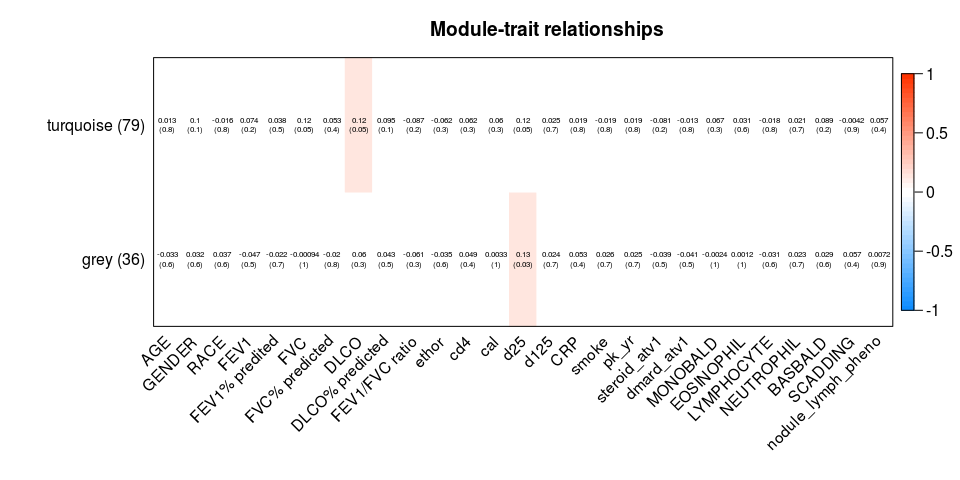

```r
labeledHeatmap(Matrix = temp.moduleTraitCor,
xLabels = rownames(my.datTraits),
#yLabels = names(MEs),
yLabels=paste(my.ME.names," (",my.ME.sizes,")",sep=""),
#ySymbols = names(MEs),
ySymbols=paste(my.ME.names," (",my.ME.sizes,")",sep=""),
colorLabels = FALSE,
colors = blueWhiteRed(50),
textMatrix = textMatrix,
#cex.text=0.8,
setStdMargins = FALSE,
cex.text = 0.5,
zlim = c(-1,1),
main = paste("Module-trait relationships"),
naColor="white")
```

#### Heatmap of gene expression and gene modules

We first generate a matrix of the clinical traits including the original data, updated data, CRP and CT scan data.

```r
# These codes only need to be run once. The clinical matrix will be saved into an RDS file.
# the old.clinic.filepath had SCADDING and more features required for the WGCNA
# the clinic.filepath had updated features. So we load in both and merge them.
old.clinic.filepath<-file.path(home.dir,"scratch/GRADS/SARC_results/Results_summary_PBMC_hg38/data/clin_data_visit1_trunc_XY.csv")
clinic.filepath<-file.path(home.dir,"scratch/GRADS/SARC_results/Results_summary_PBMC_hg38/baseline/data/clin_data_visit1_XY.csv")

old.clinic.matrix=read.csv(old.clinic.filepath,check.names=F,stringsAsFactors=F)
clinic.matrix=read.csv(clinic.filepath,check.names=F,stringsAsFactors=F)

common.features<-intersect(colnames(old.clinic.matrix),colnames(clinic.matrix))
my.data<-clinic.matrix[,common.features]

old.features<-setdiff(colnames(old.clinic.matrix),colnames(clinic.matrix))
temp<-old.clinic.matrix[,old.features]
rownames(temp)<-old.clinic.matrix[,1]
temp<-temp[my.data[,1],]
my.data<-cbind(my.data,temp)

new.features<-setdiff(colnames(clinic.matrix),colnames(old.clinic.matrix))
temp<-clinic.matrix[,new.features]
rownames(temp)<-clinic.matrix[,1]
temp<-temp[my.data[,1],]
my.data<-cbind(my.data,temp)

clinic.matrix<-my.data
rownames(clinic.matrix)<-as.matrix(clinic.matrix)[,"GRADSID"] # GRADS ID
clinic.matrix<-clinic.matrix[sample.matrix[,1],]


# add the level of CRP
clinic.filepath<-file.path(home.dir,"scratch/GRADS/SARC_results/Data_PBMC/merge_visit_patient_v1.csv")
temp.matrix<-read.csv(clinic.filepath)
rownames(temp.matrix)<-temp.matrix[,1]
temp.matrix<-temp.matrix[rownames(clinic.matrix),]
clinic.matrix<-cbind(clinic.matrix,temp.matrix[,"crp"])
colnames(clinic.matrix)[ncol(clinic.matrix)]<-"CRP"

# add CT scan data and lymph_nodule_phenotype
# load in the CT scan data.
ct.filepath<-file.path(home.dir,"scratch/GRADS/SARC_results/Data/CT_data_20170712/Sarc_ct_reads_corrected.xls")
ct.matrix<-read.xls(ct.filepath,as.is=TRUE)
rownames(ct.matrix)<-ct.matrix[,1]
ct.matrix<-ct.matrix[clinic.matrix$GRADSID,]
ct.matrix[,1]<-clinic.matrix$GRADSID
rownames(ct.matrix)<-ct.matrix[,1]
my.ct.matrix<-ct.matrix[,c("Micronodule","Micronodule_conglomerate","Med_Lymphadenopathy","Hilar_Lymphadenopathy")]
clinic.matrix<-cbind(clinic.matrix,ct.matrix[,c("Micronodule","Micronodule_conglomerate","Med_Lymphadenopathy","Hilar_Lymphadenopathy")],stringsAsFactors=F)

# load in the lymph_nodule_phenotype
data.filepath<-file.path("/home/yanxiting/driver_Grace/scratch/GRADS/SARC_results/Results_summary_PBMC_hg38/baseline/data/nodule_lymph_pheno.RDS")
new.pheno<-readRDS(data.filepath,refhook = NULL)

clinic.matrix<-cbind(clinic.matrix,new.pheno[rownames(clinic.matrix)])
colnames(clinic.matrix)[ncol(clinic.matrix)]<-"nodule_lymph_pheno"

# output the complete clinical matrix
output.filepath<-"/home/yanxiting/driver_Grace/scratch/GRADS/SARC_results/Results_summary_PBMC_hg38/baseline/data/clinic_matrix_merged.RDS"
saveRDS(clinic.matrix,file=output.filepath,refhook = NULL)
```

Then we show the heatmap of all the interferon gamma genes and mark each gene module.

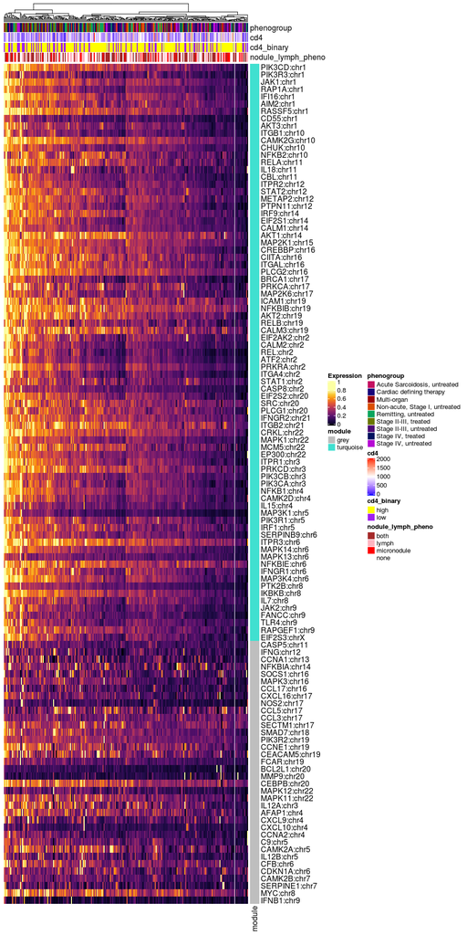

The generated pdf file can be found [here](https://drive.google.com/file/d/1_aA6feshZ3pBFuDPBttTFWq_C0iu0pGI/view?usp=sharing).

We observed:

- WGCNA identified turquoise module that includes most of the genes but there are obvious subclusters of genes within the turquoise module.
- Some genes in the grey module are also correlated with genes in the turquoise module although it’s obvious that genes with very low variation are all put into the grey module.

Based on our observations, we may simply remove genes with small variation or in the grey module for the patient clustering analysis.

## Patient clustering

### Remove grey module

We remove genes in the grey module and conduct patient clustering using K-means clustering based on the remaining genes.

- Load in gene expression data and the merged clinical matrix.

```r
# These codes should be saved in /home/xy48/Rprogram/GRADS_PBMC/WGCNA/0_CleanDataLoad.R
home.dir<-"/home/yanxiting/driver_Grace"
#home.dir<-"/home/xy48"
data.dir<-file.path(home.dir,"scratch/GRADS/SARC_results/Results_summary_PBMC_hg38")
#fpkm.filepath<-file.path(home.dir,"scratch/GRADS/SARC_results/Results_summary_PBMC_hg38/baseline/data","TPM_baseline_276_clean_GRADSID.txt")
#fpkm.filepath<-file.path(home.dir,"scratch/GRADS/SARC_results/Results_summary_PBMC_hg38/baseline/data","TPM_baseline_276_clean_celldiffadjusted_withannot.txt")
fpkm.filepath<-file.path(home.dir,"scratch/GRADS/SARC_results/Results_summary_PBMC_hg38/baseline/data_adjusted2","TPM_baseline_276_clean_celldiffadjusted_withannot.txt")

# load in the fpkm matrix
fpkm.matrix<-read.table(fpkm.filepath,sep="\t",header=T,check.names=F,as.is=TRUE,comment.char = "")
fpkm.matrix.anno<-fpkm.matrix[,1:5]
fpkm.matrix<-fpkm.matrix[,6:ncol(fpkm.matrix)]

# Load in the merged clinical data matrix
clinic.filepath<-file.path(home.dir,"scratch/GRADS/SARC_results/Results_summary_PBMC_hg38/baseline/data/clinic_matrix_merged.RDS")
clinic.matrix<-readRDS(clinic.filepath,refhook = NULL)
clinic.matrix<-clinic.matrix[colnames(fpkm.matrix),]
```

- Load in gene module assignment to remove genes of grey module from the gene expression data.

```r
# load in the gene assignment of the identified gene modules
module.filepath<-file.path(home.dir,"scratch/GRADS/SARC_results/Results_summary_PBMC_hg38/baseline/WGCNA_IFNgamma/CV0_compare/module_assignment_outliers_5.txt")
module.assign<-read.table(module.filepath,sep="\t",header=F,check.names=F)
module.gene.list<-split(as.character(module.assign[,1]),module.assign[,3])

# only keep genes in the turquoise module
temp.vect<-paste(fpkm.matrix.anno[,1],":",fpkm.matrix.anno[,"Chr"],sep="")
fpkm.matrix<-fpkm.matrix[temp.vect%in%module.gene.list[[2]],]
fpkm.matrix.anno<-fpkm.matrix.anno[temp.vect%in%module.gene.list[[2]],]
```

- Cluster patients using K-means clustering.

```r
# conduct K-means clustering using different K and visualize the clustering results to choose the best K.

# centralize the data so that the distances between patients won't be dominated by the highly expressed genes.
source(file.path(home.dir,"Rprogram/my_functions.R"))
output.dir<-file.path(home.dir,"scratch/GRADS/SARC_results/Results_summary_PBMC_hg38/baseline/kmeans_IFNgamma")
k.vect<-2:6

fig.list<-list()
for(j in 1:length(k.vect)){
kmeans.k<-k.vect[j]
dist.matrix<-t(apply(fpkm.matrix,2,rank))
dist.matrix<-my.normalize(dist.matrix)

# clustering the patients using K means clustering
patient.clustering<-kmeans(dist.matrix,centers=kmeans.k,nstart=100)
groups.4 <- patient.clustering$cluster

# output the K means clustering of patients for the module in GRADS cohort
cmd.out<-cbind(names(patient.clustering$cluster),patient.clustering$cluster)
colnames(cmd.out)<-c("KIT_ID","kmeans_cluster")
write.table(cmd.out,file=file.path(output.dir,paste("kmeans_k",kmeans.k,"_patient_clustering.txt",sep="")),append=F,sep="\t",row.names=F,col.names=T,quote=F)

# generate the heatmap of each module in GRADS cohort.
cluster.membership<-data.frame(names(groups.4),groups.4,stringsAsFactors=F)
my.hclust.order<-function(cluster.index,data.matrix,cluster.matrix,method="euclidean"){
# data.matrix rows are samples and columns are genes. This matrix has to have row names.
# cluster.matrix  a matrix with 2 columns. The first column has all the row names of data.matrix and the second column has the cluster assignment for each sample. The order of rows in cluster.matrix does not have to match that of the data.matrix
# cluster.index   an integer indicating which cluster needs to be processed.
  if(sum(cluster.matrix[,2]==cluster.index)==1){
    return(data.frame(sample_names=cluster.matrix[cluster.matrix[,2]==cluster.index,1],cluster_index=cluster.index))
  }else{
    return(data.frame(sample_names=cluster.matrix[cluster.matrix[,2]==cluster.index,1][hclust(dist(data.matrix[cluster.matrix[cluster.matrix[,2]==cluster.index,1],],method=method))$order],cluster_index=rep(cluster.index,sum(cluster.matrix[,2]==cluster.index))))
  }
}

cluster.mem.list<-lapply(1:kmeans.k,my.hclust.order,data.matrix=dist.matrix,cluster.matrix=cluster.membership)
temp.list<-lapply(cluster.mem.list,function(x){return(as.matrix(x)[,1])})
temp.list<-unlist(temp.list)
sample.list<-temp.list

temp.list<-lapply(cluster.mem.list,function(x){return(as.matrix(x)[,2])})
temp.list<-unlist(temp.list)
sample.list.cluster<-temp.list
# draw the heatmap
fpkm.mod<-my.normalize(fpkm.matrix[,sample.list])
temp.color<-my.color.gen.cat(sample.list.cluster)$color.num
#      output.filepath<-file.path(output.dir,paste("heatmap_",chosen.modules[i],"_kmeans_k",kmeans.k,".eps",sep=""))
#      postscript(output.filepath,width=15,height=15,paper="special")
temp.breaks<-seq(from=-2.7,to=3.1,length=501)

fig.list[[j]]<-as.grob(~heatmap.2(as.matrix(fpkm.mod),breaks=temp.breaks,scale="none",dendrogram="row",Rowv=T,Colv=F,col=colorpanel(500,low="purple",mid="grey",high="yellow"),cexCol=1,trace="none",density.info="none",key=TRUE,symkey=FALSE,keysize=0.8,na.color="grey",ColSideColors=temp.color,main=paste("k=",kmeans.k,sep="")))

}

do.call(grid.arrange,c(fig.list,ncol=2))
```

[output not shown]

```r
#g<-do.call(marrangeGrob,c(fig.list,nrow=1,ncol=2))
g<-marrangeGrob(fig.list,nrow=1,ncol=2)
output.filepath<-file.path(output.dir,paste("heatmap_kmeans_allcomparison.pdf",sep=""))
ggsave(file=output.filepath,width = 200, height =  200, units = "mm", g)
```

#### Comparing clinical traits across all clusters

```r
# load in the clustering results
kmeans.filepath<-file.path(home.dir,"scratch/GRADS/SARC_results/Results_summary_PBMC_hg38/baseline/kmeans_IFNgamma","kmeans_k6_patient_clustering.txt")
kmeans.k<-6
kmeans.clustering<-read.table(kmeans.filepath,sep="\t",header=T,check.names=F)
temp<-kmeans.clustering[,2]
names(temp)<-kmeans.clustering[,1]
kmeans.clustering<-temp
kmeans.clustering<-kmeans.clustering[rownames(clinic.matrix)]

# correlate the clustering results with clinical traits using
feature.names<-c("GENDER","RACE","AGE","ethor","wbc","cd4","cal","d25","d125","crp","p_lymph","p_mono","p_neut","p_eos","p_baso","BDFVC","POSTFVC","FVCPRED","BDFEV1","POSTFEV1","FEV1PRED","BDDLCO","PREDDLCO","SCADDING","PHENGRP","smoke","steroid_atv1","dmard_atv1","nodule_lymph_pheno")
feature.types<-c("cat","cat","con","cat",rep("con",19),"cat","cat","cat","cat","cat","cat")

my.data<-cbind(clinic.matrix,kmeans.clustering)

orig_opt <- options()$qwraps2_markup
options(qwraps2_markup = "markdown")

my_summary<-list( "Gender"=list("female"= ~ qwraps2::n_perc0(GENDER==0,na_rm = T),"male"=~ qwraps2::n_perc0(GENDER==1,na_rm = T)),
                 "Race"=list("White"= ~ qwraps2::n_perc0(RACE==0,na_rm = T),
                             "Black"=~ qwraps2::n_perc0(RACE==1,na_rm = T),
                             "Other"=~ qwraps2::n_perc0(RACE>1,na_rm = T)),
                 "Age"=list("mean (sd)"= ~ qwraps2::mean_sd(AGE,na_rm = T)),
                 "ethor"=list("yes"= ~ qwraps2::n_perc0(ethor==1,na_rm = T),
                              "no"=~ qwraps2::n_perc0(ethor==0,na_rm = T)),
                 "WBC"=list("mean (sd)"= ~ qwraps2::mean_sd(wbc,na_rm = T)),
                 "CD4"=list("mean (sd)"= ~ qwraps2::mean_sd(cd4,na_rm = T)),
                 "CALCIUM"=list("mean (sd)"= ~ qwraps2::mean_sd(cal,na_rm = T)),
                 "D25"=list("mean (sd)"= ~ qwraps2::mean_sd(d25,na_rm = T)),
                 "D125"=list("mean (sd)"= ~ qwraps2::mean_sd(d125,na_rm = T)),
                 "CRP"=list("mean (sd)"= ~ qwraps2::mean_sd(crp,na_rm = T)),
                 "Lymphocytes %"=list("mean (sd)"= ~ qwraps2::mean_sd(p_lymph,na_rm = T)),
                 "Monocytes %"=list("mean (sd)"= ~ qwraps2::mean_sd(p_mono,na_rm = T)),
                 "Neutrophils %"=list("mean (sd)"= ~ qwraps2::mean_sd(p_neut,na_rm = T)),
                 "Eosinophils %"=list("mean (sd)"= ~ qwraps2::mean_sd(p_eos,na_rm = T)),
                 "Basophils %"=list("mean (sd)"= ~ qwraps2::mean_sd(p_baso,na_rm = T)),
                 "FVC (pre)"=list("mean (sd)"= ~ qwraps2::mean_sd(BDFVC,na_rm = T)),
                 "FVC (post)"=list("mean (sd)"= ~ qwraps2::mean_sd(POSTFVC,na_rm = T)),
                 "FVC %"=list("mean (sd)"= ~ qwraps2::mean_sd(FVCPRED,na_rm = T)),
                 "FEV1 (pre)"=list("mean (sd)"= ~ qwraps2::mean_sd(BDFEV1,na_rm = T)),
                 "FEV1 (post)"=list("mean (sd)"= ~ qwraps2::mean_sd(POSTFEV1,na_rm = T)),
                 "FEV1 %"=list("mean (sd)"= ~ qwraps2::mean_sd(FEV1PRED,na_rm = T)),
                 "DLCO (pre)"=list("mean (sd)"= ~ qwraps2::mean_sd(BDDLCO,na_rm = T)),
                 "DLCO %"=list("mean (sd)"= ~ qwraps2::mean_sd(PREDDLCO,na_rm = T)),
                 "Scadding Stage"=list("0"= ~ qwraps2::n_perc0(SCADDING=="0",na_rm = T),
                                       "I"=~ qwraps2::n_perc0(SCADDING=="I",na_rm = T),
                                       "II"= ~ qwraps2::n_perc0(SCADDING=="II",na_rm = T),
                                       "III"= ~ qwraps2::n_perc0(SCADDING=="III",na_rm = T),
                                       "IV"= ~ qwraps2::n_perc0(SCADDING=="IV",na_rm = T)),
                 "Phenotypic Group"=list("Multi-organ"= ~ qwraps2::n_perc0(PHENGRP=="Multi-organ",na_rm = T),
                                "Remitting, untreated"= ~ qwraps2::n_perc0(PHENGRP=="Remitting, untreated",na_rm = T),
                                "Cardiac defining therapy"= ~ qwraps2::n_perc0(PHENGRP=="Cardiac defining therapy",na_rm = T),
                      "Acute SARC, untreated"= ~ qwraps2::n_perc0(PHENGRP=="Acute Sarcoidosis, untreated",na_rm = T),
                      "Stage I, untreated"= ~ qwraps2::n_perc0(PHENGRP=="Non-acute, Stage I, untreated",na_rm = T),
                      "Stage II-III, untreated"= ~ qwraps2::n_perc0(PHENGRP=="Stage II-III, untreated",na_rm = T),
                      "Stage IV, untreated"= ~ qwraps2::n_perc0(PHENGRP=="Stage IV, untreated",na_rm = T),
                      "Stage II-III, treated"= ~ qwraps2::n_perc0(PHENGRP=="Stage II-III, treated",na_rm = T),
                      "Stage IV, treated"= ~ qwraps2::n_perc0(PHENGRP=="Stage IV, treated",na_rm = T)),
                 "Smoking"=list("yes"= ~ qwraps2::n_perc0(smoke==1,na_rm = T),"no"=~ qwraps2::n_perc0(smoke==0,na_rm = T)),
                 "Steroid usage"=list("yes"= ~ qwraps2::n_perc0(steroid_atv1==1,na_rm = T),"no"=~ qwraps2::n_perc0(steroid_atv1==0,na_rm = T)),
                 "Dmard"=list("yes"= ~ qwraps2::n_perc0(dmard_atv1==1,na_rm = T),"no"=~ qwraps2::n_perc0(dmard_atv1==0,na_rm = T)),
                 "Lymph Nodule Pheno"=list("none"= ~ qwraps2::n_perc0(nodule_lymph_pheno=="none",na_rm = T),
                "lymph only"=~ qwraps2::n_perc0(nodule_lymph_pheno=="lymph",na_rm = T),
                "both"= ~ qwraps2::n_perc0(nodule_lymph_pheno=="both",na_rm = T),
                "micronodule only"= ~ qwraps2::n_perc0(nodule_lymph_pheno=="micronodule",na_rm = T))
                 )

#whole_table<-summary_table(my.data,my_summary,by="kmeans.clustering")
#whole_table

# add p value into the summary table
pvalue.vect<-numeric()
for(i in 1:length(feature.names)){
  if(feature.types[i]=="con"){
    pvalue.vect<-c(pvalue.vect,kruskal.test(clinic.matrix[,feature.names[i]] ~ as.factor(my.data$kmeans.clustering))$p.value)
  }else{
    temp.vect<-clinic.matrix[,feature.names[i]]
    if(feature.names[i]=="RACE"){
      temp.vect[temp.vect>1]<-NA
    }
    y<-my.data$kmeans.clustering
    y<-y[!is.na(temp.vect)]
    temp.vect<-temp.vect[!is.na(temp.vect)]
    pvalue.vect<-c(pvalue.vect,chisq.test(x=as.factor(temp.vect),y=as.factor(y))$p.value)
  }
}
```

```
Chi-squared approximation may be incorrectChi-squared approximation may be incorrectChi-squared approximation may be incorrectChi-squared approximation may be incorrectChi-squared approximation may be incorrect
```

```r
my_summary<-setNames(my_summary,paste(names(my_summary),": P-value=",formatC(pvalue.vect,digits=4),sep=""))

whole_table<-summary_table(my.data,my_summary,by="kmeans.clustering")
whole_table
```

|  | 1 (N = 27) | 2 (N = 28) | 3 (N = 33) | 4 (N = 21) | 5 (N = 65) | 6 (N = 95) |
| --- | --- | --- | --- | --- | --- | --- |
| **Gender: P-value=0.3314** |  |  |  |  |  |  |
| female | 12 (44) | 12 (43) | 19 (58) | 8 (38) | 35 (54) | 56 (60) |
| male | 15 (56) | 16 (57) | 14 (42) | 13 (62) | 30 (46) | 38 (40) |
| **Race: P-value=0.01506** |  |  |  |  |  |  |
| White | 23 (85) | 16 (57) | 22 (67) | 15 (71) | 53 (82) | 72 (76) |
| Black | 2 (7) | 12 (43) | 11 (33) | 4 (19) | 9 (14) | 21 (22) |
| Other | 2 (7) | 0 (0) | 0 (0) | 2 (10) | 3 (5) | 2 (2) |
| **Age: P-value=0.3169** |  |  |  |  |  |  |
| mean (sd) | 56.24 ± 10.23 | 51.93 ± 9.95 | 52.51 ± 10.11 | 52.34 ± 11.86 | 51.11 ± 9.28 | 94; 51.52 ± 10.81 |
| **ethor: P-value=0.4569** |  |  |  |  |  |  |
| yes | 18 (67) | 13 (46) | 21 (64) | 12 (57) | 34 (52) | 60 (63) |
| no | 9 (33) | 15 (54) | 12 (36) | 9 (43) | 31 (48) | 35 (37) |
| **WBC: P-value=0.4189** |  |  |  |  |  |  |
| mean (sd) | 7.18 ± 2.81 | 7.03 ± 3.21 | 6.25 ± 2.28 | 7.23 ± 3.12 | 6.60 ± 2.20 | 6.47 ± 1.85 |
| **CD4: P-value=0.6127** |  |  |  |  |  |  |
| mean (sd) | 627.59 ± 348.49 | 704.89 ± 468.94 | 605.06 ± 408.16 | 579.86 ± 280.74 | 709.89 ± 422.94 | 601.27 ± 349.09 |
| **CALCIUM: P-value=0.8341** |  |  |  |  |  |  |
| mean (sd) | 9.02 ± 2.43 | 8.83 ± 3.10 | 9.60 ± 0.47 | 9.54 ± 0.49 | 9.24 ± 2.15 | 9.56 ± 0.41 |
| **D25: P-value=0.04813** |  |  |  |  |  |  |
| mean (sd) | 32.41 ± 17.67 | 26.00 ± 11.76 | 22.30 ± 13.35 | 30.90 ± 16.58 | 30.02 ± 13.80 | 26.98 ± 13.35 |
| **D125: P-value=0.7138** |  |  |  |  |  |  |
| mean (sd) | 60.96 ± 24.36 | 49.43 ± 28.89 | 58.82 ± 26.48 | 55.43 ± 23.45 | 53.72 ± 26.84 | 54.38 ± 24.36 |
| **CRP: P-value=0.8295** |  |  |  |  |  |  |
| mean (sd) | 6.67 ± 26.31 | 4.76 ± 7.35 | 3.67 ± 5.37 | 4.32 ± 7.22 | 3.00 ± 3.70 | 2.62 ± 4.68 |
| **Lymphocytes %: P-value=0.2342** |  |  |  |  |  |  |
| mean (sd) | 21.81 ± 10.37 | 22.92 ± 10.62 | 21.40 ± 7.72 | 19.16 ± 7.66 | 27.26 ± 26.51 | 23.10 ± 9.32 |
| **Monocytes %: P-value=0.477** |  |  |  |  |  |  |
| mean (sd) | 8.25 ± 3.32 | 7.58 ± 2.11 | 9.25 ± 3.66 | 8.93 ± 3.60 | 8.33 ± 2.25 | 8.21 ± 2.98 |
| **Neutrophils %: P-value=0.6429** |  |  |  |  |  |  |
| mean (sd) | 66.16 ± 12.10 | 66.08 ± 11.90 | 65.48 ± 9.96 | 68.67 ± 10.19 | 63.89 ± 10.01 | 65.17 ± 11.87 |
| **Eosinophils %: P-value=0.8292** |  |  |  |  |  |  |
| mean (sd) | 3.20 ± 2.09 | 2.87 ± 2.10 | 3.33 ± 3.21 | 2.49 ± 2.23 | 2.92 ± 1.84 | 2.87 ± 2.21 |
| **Basophils %: P-value=0.2709** |  |  |  |  |  |  |
| mean (sd) | 0.61 ± 0.38 | 0.48 ± 0.39 | 0.61 ± 0.35 | 0.60 ± 0.85 | 0.64 ± 0.46 | 0.63 ± 0.48 |
| **FVC (pre): P-value=0.3526** |  |  |  |  |  |  |
| mean (sd) | 3.86 ± 1.06 | 3.50 ± 1.04 | 3.56 ± 1.15 | 3.16 ± 1.70 | 64; 3.73 ± 1.26 | 94; 3.44 ± 1.46 |
| **FVC (post): P-value=0.6096** |  |  |  |  |  |  |
| mean (sd) | 3.63 ± 1.55 | 3.63 ± 1.13 | 3.62 ± 1.12 | 3.28 ± 1.70 | 64; 3.70 ± 1.25 | 94; 3.37 ± 1.54 |
| **FVC %: P-value=0.07179** |  |  |  |  |  |  |
| mean (sd) | 89.74 ± 21.81 | 83.36 ± 16.76 | 84.00 ± 28.74 | 75.38 ± 23.81 | 64; 90.34 ± 18.86 | 94; 81.03 ± 30.76 |
| **FEV1 (pre): P-value=0.6664** |  |  |  |  |  |  |
| mean (sd) | 2.86 ± 0.88 | 2.61 ± 0.88 | 2.67 ± 0.92 | 2.33 ± 1.46 | 64; 2.69 ± 1.07 | 94; 2.54 ± 1.13 |
| **FEV1 (post): P-value=0.7611** |  |  |  |  |  |  |
| mean (sd) | 2.74 ± 1.30 | 2.79 ± 0.94 | 2.80 ± 0.91 | 2.48 ± 1.44 | 64; 2.75 ± 1.06 | 94; 2.55 ± 1.26 |
| **FEV1 %: P-value=0.2051** |  |  |  |  |  |  |
| mean (sd) | 89.00 ± 24.55 | 82.43 ± 20.80 | 83.76 ± 30.38 | 73.33 ± 25.01 | 64; 86.06 ± 22.70 | 94; 79.04 ± 32.28 |
| **DLCO (pre): P-value=0.383** |  |  |  |  |  |  |
| mean (sd) | 21.27 ± 11.53 | 24.96 ± 9.14 | 23.95 ± 8.57 | 21.44 ± 11.56 | 64; 23.59 ± 7.42 | 94; 20.60 ± 9.71 |
| **DLCO %: P-value=0.4872** |  |  |  |  |  |  |
| mean (sd) | 73.30 ± 34.54 | 84.61 ± 24.97 | 87.48 ± 27.04 | 75.90 ± 36.32 | 64; 81.95 ± 23.55 | 94; 75.04 ± 28.76 |
| **Scadding Stage: P-value=0.1493** |  |  |  |  |  |  |
| 0 | 3 (11) | 6 (21) | 1 (3) | 1 (5) | 6 (9) | 10 (11) |
| I | 2 (7) | 5 (18) | 9 (27) | 7 (33) | 24 (37) | 18 (19) |
| II | 9 (33) | 9 (32) | 13 (39) | 4 (19) | 20 (31) | 33 (35) |
| III | 4 (15) | 2 (7) | 5 (15) | 2 (10) | 5 (8) | 16 (17) |
| IV | 9 (33) | 5 (18) | 5 (15) | 7 (33) | 9 (14) | 18 (19) |
| **Phenotypic Group: P-value=0.004854** |  |  |  |  |  |  |
| Multi-organ | 3 (11) | 3 (11) | 2 (6) | 4 (19) | 4 (6) | 8 (8) |
| Remitting, untreated | 2 (7) | 7 (25) | 5 (15) | 2 (10) | 10 (15) | 14 (15) |
| Cardiac defining therapy | 2 (7) | 4 (14) | 3 (9) | 3 (14) | 3 (5) | 17 (18) |
| Acute SARC, untreated | 1 (4) | 0 (0) | 5 (15) | 0 (0) | 2 (3) | 4 (4) |
| Stage I, untreated | 1 (4) | 1 (4) | 2 (6) | 1 (5) | 17 (26) | 7 (7) |
| Stage II-III, untreated | 4 (15) | 7 (25) | 6 (18) | 2 (10) | 10 (15) | 16 (17) |
| Stage IV, untreated | 6 (22) | 0 (0) | 1 (3) | 5 (24) | 2 (3) | 9 (9) |
| Stage II-III, treated | 5 (19) | 2 (7) | 6 (18) | 3 (14) | 11 (17) | 12 (13) |
| Stage IV, treated | 3 (11) | 4 (14) | 3 (9) | 1 (5) | 6 (9) | 8 (8) |
| **Smoking: P-value=0.8792** |  |  |  |  |  |  |
| yes | 9 (33) | 7 (25) | 13 (39) | 6 (29) | 21 (32) | 28 (30) |
| no | 18 (67) | 21 (75) | 20 (61) | 15 (71) | 44 (68) | 66 (70) |
| **Steroid usage: P-value=0.1705** |  |  |  |  |  |  |
| yes | 7 (26) | 5 (18) | 3 (9) | 7 (33) | 9 (14) | 22 (24) |
| no | 20 (74) | 23 (82) | 30 (91) | 14 (67) | 55 (86) | 70 (76) |
| **Dmard: P-value=0.4599** |  |  |  |  |  |  |
| yes | 10 (37) | 6 (21) | 13 (39) | 6 (29) | 15 (23) | 25 (27) |
| no | 17 (63) | 22 (79) | 20 (61) | 15 (71) | 50 (77) | 68 (73) |
| **Lymph Nodule Pheno: P-value=0.3725** |  |  |  |  |  |  |
| none | 7 (26) | 9 (35) | 7 (22) | 6 (29) | 12 (19) | 25 (27) |
| lymph only | 8 (30) | 3 (12) | 10 (31) | 7 (33) | 23 (36) | 20 (22) |
| both | 11 (41) | 8 (31) | 8 (25) | 4 (19) | 22 (34) | 33 (36) |
| micronodule only | 1 (4) | 6 (23) | 7 (22) | 4 (19) | 7 (11) | 14 (15) |

```r
output.filepath<-file.path(output.dir,"kmeans_IFNgamma","IFNgamma_WGCNA_kmeans_clustering_summarytable.rds")
saveRDS(whole_table,file=output.filepath,refhook = NULL)

my.data.2<-my.data[,feature.names]
my.data.2<-cbind(my.data.2,my.data$kmeans.clustering)
colnames(my.data.2)[ncol(my.data.2)]<-"kmeans.clustering"
my.data.2[my.data.2<0]<-NA
```

```
'<' not meaningful for factors
```

```r
for(j in 1:length(feature.names)){
  if(feature.types[j]=="cat"){
    my.data.2[,j]<-as.factor(my.data.2[,j])
  }
}
my.data.2[,ncol(my.data.2)]<-as.factor(my.data.2[,ncol(my.data.2)])
x<-summary_table(my.data.2,qsummary(my.data.2),by="kmeans.clustering")
x
```

|  | 1 (N = 27) | 2 (N = 28) | 3 (N = 33) | 4 (N = 21) | 5 (N = 65) | 6 (N = 95) |
| --- | --- | --- | --- | --- | --- | --- |
| **GENDER** |  |  |  |  |  |  |
| 0 | 12 (44) | 12 (43) | 19 (58) | 8 (38) | 35 (54) | 56 (60) |
| 1 | 15 (56) | 16 (57) | 14 (42) | 13 (62) | 30 (46) | 38 (40) |
| Unknown/Missing | 0 (0.00%) | 0 (0.00%) | 0 (0.00%) | 0 (0.00%) | 0 (0.00%) | 1 (1.05%) |
| **RACE** |  |  |  |  |  |  |
| 0 | 23 (85) | 16 (57) | 22 (67) | 15 (71) | 53 (82) | 72 (76) |
| 1 | 2 (7) | 12 (43) | 11 (33) | 4 (19) | 9 (14) | 21 (22) |
| 2 | 0 (0) | 0 (0) | 0 (0) | 0 (0) | 0 (0) | 1 (1) |
| 3 | 0 (0) | 0 (0) | 0 (0) | 0 (0) | 1 (2) | 0 (0) |
| 5 | 1 (4) | 0 (0) | 0 (0) | 2 (10) | 1 (2) | 0 (0) |
| 6 | 1 (4) | 0 (0) | 0 (0) | 0 (0) | 1 (2) | 1 (1) |
| **AGE** |  |  |  |  |  |  |
| minimum | 27.33 | 25.98 | 32.75 | 29.93 | 31.62 | 26.29 |
| median (IQR) | 56.53 (51.79, 62.50) | 54.03 (47.28, 57.46) | 51.90 (44.25, 58.91) | 52.79 (44.68, 62.54) | 51.62 (45.63, 57.42) | 52.46 (44.94, 59.98) |
| mean (sd) | 56.24 ± 10.23 | 51.93 ± 9.95 | 52.51 ± 10.11 | 52.34 ± 11.86 | 51.11 ± 9.28 | 51.52 ± 10.81 |
| maximum | 73.50 | 71.39 | 77.29 | 72.30 | 74.77 | 69.58 |
| Unknown/Missing | 0 (0.00%) | 0 (0.00%) | 0 (0.00%) | 0 (0.00%) | 0 (0.00%) | 1 (1.05%) |
| **ethor** |  |  |  |  |  |  |
| 0 | 9 (33) | 15 (54) | 12 (36) | 9 (43) | 31 (48) | 35 (37) |
| 1 | 18 (67) | 13 (46) | 21 (64) | 12 (57) | 34 (52) | 60 (63) |
| **wbc** |  |  |  |  |  |  |
| minimum | 3.80 | 2.90 | 3.30 | 3.60 | 3.30 | 2.90 |
| median (IQR) | 6.50 (5.30, 8.00) | 6.80 (5.70, 8.55) | 5.70 (4.60, 6.70) | 6.50 (5.70, 7.80) | 6.10 (5.00, 7.60) | 6.10 (5.00, 7.50) |
| mean (sd) | 7.18 ± 2.81 | 7.40 ± 2.58 | 6.25 ± 2.28 | 7.23 ± 3.12 | 6.60 ± 2.20 | 6.47 ± 1.85 |
| maximum | 16.10 | 13.20 | 12.60 | 17.10 | 12.20 | 12.10 |
| Unknown/Missing | 0 (0.00%) | 1 (3.57%) | 0 (0.00%) | 0 (0.00%) | 0 (0.00%) | 0 (0.00%) |
| **cd4** |  |  |  |  |  |  |
| minimum | 99 | 121 | 106 | 237 | 115 | 28 |
| median (IQR) | 581 (375.00, 881.50) | 644 (428.50, 988.00) | 548.50 (317.50, 986.25) | 498 (366.00, 648.00) | 667.50 (416.75, 1,032.50) | 565.00 (395.75, 782.50) |
| mean (sd) | 627.59 ± 348.49 | 731.07 ± 456.55 | 624.03 ± 399.63 | 579.86 ± 280.74 | 744.35 ± 401.90 | 634.80 ± 327.28 |

[output cut: 141 more lines]

```r
output.filepath<-file.path(output.dir,"kmeans_IFNgamma","IFNgamma_WGCNA_kmeans_clustering_summarytable2.rds")
saveRDS(x,file=output.filepath,refhook = NULL)
```

#### Comparing clinical trait between two extreme clusters

We chose cluster 5 and 6 because in heatmap_kmeans_allcomparison.pdf, cluster 5 and 6 have the most distinguished expression patterns. We directly compare the clinical traits between these two groups of patients to see what clinical traits are associated.

```r
# load in the clustering results
kmeans.filepath<-file.path(home.dir,"scratch/GRADS/SARC_results/Results_summary_PBMC_hg38/baseline/kmeans_IFNgamma","kmeans_k6_patient_clustering.txt")
kmeans.k<-6
kmeans.clustering<-read.table(kmeans.filepath,sep="\t",header=T,check.names=F)
temp<-kmeans.clustering[,2]
names(temp)<-kmeans.clustering[,1]
kmeans.clustering<-temp
kmeans.clustering<-kmeans.clustering[rownames(clinic.matrix)]

# correlate the clustering results with clinical traits using
feature.names<-c("GENDER","RACE","AGE","ethor","wbc","cd4","cal","d25","d125","crp","p_lymph","p_mono","p_neut","p_eos","p_baso","BDFVC","POSTFVC","FVCPRED","BDFEV1","POSTFEV1","FEV1PRED","BDDLCO","PREDDLCO","SCADDING","PHENGRP","smoke","steroid_atv1","dmard_atv1","nodule_lymph_pheno")
feature.types<-c("cat","cat","con","cat",rep("con",19),"cat","cat","cat","cat","cat","cat")

my.data<-cbind(clinic.matrix,kmeans.clustering)

my.data<-my.data[my.data$kmeans.clustering%in%c(5,6),]
my.clinic.matrix<-clinic.matrix[my.data$GRADSID,]
orig_opt <- options()$qwraps2_markup
options(qwraps2_markup = "markdown")

my_summary<-list( "Gender"=list("female"= ~ qwraps2::n_perc0(GENDER==0,na_rm = T),"male"=~ qwraps2::n_perc0(GENDER==1,na_rm = T)),
                 "Race"=list("White"= ~ qwraps2::n_perc0(RACE==0,na_rm = T),
                             "Black"=~ qwraps2::n_perc0(RACE==1,na_rm = T),
                             "Other"=~ qwraps2::n_perc0(RACE>1,na_rm = T)),
                 "Age"=list("mean (sd)"= ~ qwraps2::mean_sd(AGE,na_rm = T)),
                 "ethor"=list("yes"= ~ qwraps2::n_perc0(ethor==1,na_rm = T),
                              "no"=~ qwraps2::n_perc0(ethor==0,na_rm = T)),
                 "WBC"=list("mean (sd)"= ~ qwraps2::mean_sd(wbc,na_rm = T)),
                 "CD4"=list("mean (sd)"= ~ qwraps2::mean_sd(cd4,na_rm = T)),
                 "CALCIUM"=list("mean (sd)"= ~ qwraps2::mean_sd(cal,na_rm = T)),
                 "D25"=list("mean (sd)"= ~ qwraps2::mean_sd(d25,na_rm = T)),
                 "D125"=list("mean (sd)"= ~ qwraps2::mean_sd(d125,na_rm = T)),
                 "CRP"=list("mean (sd)"= ~ qwraps2::mean_sd(crp,na_rm = T)),
                 "Lymphocytes %"=list("mean (sd)"= ~ qwraps2::mean_sd(p_lymph,na_rm = T)),
                 "Monocytes %"=list("mean (sd)"= ~ qwraps2::mean_sd(p_mono,na_rm = T)),
                 "Neutrophils %"=list("mean (sd)"= ~ qwraps2::mean_sd(p_neut,na_rm = T)),
                 "Eosinophils %"=list("mean (sd)"= ~ qwraps2::mean_sd(p_eos,na_rm = T)),
                 "Basophils %"=list("mean (sd)"= ~ qwraps2::mean_sd(p_baso,na_rm = T)),
                 "FVC (pre)"=list("mean (sd)"= ~ qwraps2::mean_sd(BDFVC,na_rm = T)),
                 "FVC (post)"=list("mean (sd)"= ~ qwraps2::mean_sd(POSTFVC,na_rm = T)),
                 "FVC %"=list("mean (sd)"= ~ qwraps2::mean_sd(FVCPRED,na_rm = T)),
                 "FEV1 (pre)"=list("mean (sd)"= ~ qwraps2::mean_sd(BDFEV1,na_rm = T)),
                 "FEV1 (post)"=list("mean (sd)"= ~ qwraps2::mean_sd(POSTFEV1,na_rm = T)),
                 "FEV1 %"=list("mean (sd)"= ~ qwraps2::mean_sd(FEV1PRED,na_rm = T)),
                 "DLCO (pre)"=list("mean (sd)"= ~ qwraps2::mean_sd(BDDLCO,na_rm = T)),
                 "DLCO %"=list("mean (sd)"= ~ qwraps2::mean_sd(PREDDLCO,na_rm = T)),
                 "Scadding Stage"=list("0"= ~ qwraps2::n_perc0(SCADDING=="0",na_rm = T),
                                       "I"=~ qwraps2::n_perc0(SCADDING=="I",na_rm = T),
                                       "II"= ~ qwraps2::n_perc0(SCADDING=="II",na_rm = T),
                                       "III"= ~ qwraps2::n_perc0(SCADDING=="III",na_rm = T),
                                       "IV"= ~ qwraps2::n_perc0(SCADDING=="IV",na_rm = T)),
                 "Phenotypic Group"=list("Multi-organ"= ~ qwraps2::n_perc0(PHENGRP=="Multi-organ",na_rm = T),
                                "Remitting, untreated"= ~ qwraps2::n_perc0(PHENGRP=="Remitting, untreated",na_rm = T),
                                "Cardiac defining therapy"= ~ qwraps2::n_perc0(PHENGRP=="Cardiac defining therapy",na_rm = T),
                      "Acute SARC, untreated"= ~ qwraps2::n_perc0(PHENGRP=="Acute Sarcoidosis, untreated",na_rm = T),
                      "Stage I, untreated"= ~ qwraps2::n_perc0(PHENGRP=="Non-acute, Stage I, untreated",na_rm = T),
                      "Stage II-III, untreated"= ~ qwraps2::n_perc0(PHENGRP=="Stage II-III, untreated",na_rm = T),
                      "Stage IV, untreated"= ~ qwraps2::n_perc0(PHENGRP=="Stage IV, untreated",na_rm = T),
                      "Stage II-III, treated"= ~ qwraps2::n_perc0(PHENGRP=="Stage II-III, treated",na_rm = T),
                      "Stage IV, treated"= ~ qwraps2::n_perc0(PHENGRP=="Stage IV, treated",na_rm = T)),
                 "Smoking"=list("yes"= ~ qwraps2::n_perc0(smoke==1,na_rm = T),"no"=~ qwraps2::n_perc0(smoke==0,na_rm = T)),
                 "Steroid usage"=list("yes"= ~ qwraps2::n_perc0(steroid_atv1==1,na_rm = T),"no"=~ qwraps2::n_perc0(steroid_atv1==0,na_rm = T)),
                 "Dmard"=list("yes"= ~ qwraps2::n_perc0(dmard_atv1==1,na_rm = T),"no"=~ qwraps2::n_perc0(dmard_atv1==0,na_rm = T)),
                 "Lymph Nodule Pheno"=list("none"= ~ qwraps2::n_perc0(nodule_lymph_pheno=="none",na_rm = T),
                "lymph only"=~ qwraps2::n_perc0(nodule_lymph_pheno=="lymph",na_rm = T),
                "both"= ~ qwraps2::n_perc0(nodule_lymph_pheno=="both",na_rm = T),
                "micronodule only"= ~ qwraps2::n_perc0(nodule_lymph_pheno=="micronodule",na_rm = T))
                 )

#whole_table<-summary_table(my.data,my_summary,by="kmeans.clustering")
#whole_table

# add p value into the summary table
pvalue.vect<-numeric()
for(i in 1:length(feature.names)){
  if(feature.types[i]=="con"){
    pvalue.vect<-c(pvalue.vect,kruskal.test(my.clinic.matrix[,feature.names[i]] ~ as.factor(my.data$kmeans.clustering))$p.value)
  }else{
    temp.vect<-my.clinic.matrix[,feature.names[i]]
    if(feature.names[i]=="RACE"){
      temp.vect[temp.vect>1]<-NA
    }
    y<-my.data$kmeans.clustering
    y<-y[!is.na(temp.vect)]
    temp.vect<-temp.vect[!is.na(temp.vect)]
    pvalue.vect<-c(pvalue.vect,chisq.test(x=as.factor(temp.vect),y=as.factor(y))$p.value)
  }
}
```

```
Chi-squared approximation may be incorrectChi-squared approximation may be incorrect
```

```r
my_summary<-setNames(my_summary,paste(names(my_summary),": P-value=",formatC(pvalue.vect,digits=4),sep=""))

whole_table<-summary_table(my.data,my_summary,by="kmeans.clustering")
whole_table
```

|  | 5 (N = 65) | 6 (N = 95) |
| --- | --- | --- |
| **Gender: P-value=0.5791** |  |  |
| female | 35 (54) | 56 (60) |
| male | 30 (46) | 38 (40) |
| **Race: P-value=0.2995** |  |  |
| White | 53 (82) | 72 (76) |
| Black | 9 (14) | 21 (22) |
| Other | 3 (5) | 2 (2) |
| **Age: P-value=0.5656** |  |  |
| mean (sd) | 51.11 ± 9.28 | 94; 51.52 ± 10.81 |
| **ethor: P-value=0.2279** |  |  |
| yes | 34 (52) | 60 (63) |
| no | 31 (48) | 35 (37) |
| **WBC: P-value=0.9612** |  |  |
| mean (sd) | 6.60 ± 2.20 | 6.47 ± 1.85 |
| **CD4: P-value=0.1208** |  |  |
| mean (sd) | 709.89 ± 422.94 | 601.27 ± 349.09 |
| **CALCIUM: P-value= 0.48** |  |  |
| mean (sd) | 9.24 ± 2.15 | 9.56 ± 0.41 |
| **D25: P-value=0.1346** |  |  |
| mean (sd) | 30.02 ± 13.80 | 26.98 ± 13.35 |
| **D125: P-value=0.9349** |  |  |
| mean (sd) | 53.72 ± 26.84 | 54.38 ± 24.36 |
| **CRP: P-value=0.2466** |  |  |
| mean (sd) | 3.00 ± 3.70 | 2.62 ± 4.68 |
| **Lymphocytes %: P-value=0.3898** |  |  |
| mean (sd) | 27.26 ± 26.51 | 23.10 ± 9.32 |
| **Monocytes %: P-value=0.5782** |  |  |
| mean (sd) | 8.33 ± 2.25 | 8.21 ± 2.98 |
| **Neutrophils %: P-value=0.5559** |  |  |
| mean (sd) | 63.89 ± 10.01 | 65.17 ± 11.87 |
| **Eosinophils %: P-value=0.585** |  |  |
| mean (sd) | 2.92 ± 1.84 | 2.87 ± 2.21 |
| **Basophils %: P-value=0.7809** |  |  |
| mean (sd) | 0.64 ± 0.46 | 0.63 ± 0.48 |
| **FVC (pre): P-value=0.09317** |  |  |
| mean (sd) | 64; 3.73 ± 1.26 | 94; 3.44 ± 1.46 |
| **FVC (post): P-value=0.09918** |  |  |
| mean (sd) | 64; 3.70 ± 1.25 | 94; 3.37 ± 1.54 |
| **FVC %: P-value=0.1601** |  |  |
| mean (sd) | 64; 90.34 ± 18.86 | 94; 81.03 ± 30.76 |
| **FEV1 (pre): P-value=0.3543** |  |  |
| mean (sd) | 64; 2.69 ± 1.07 | 94; 2.54 ± 1.13 |
| **FEV1 (post): P-value=0.2668** |  |  |
| mean (sd) | 64; 2.75 ± 1.06 | 94; 2.55 ± 1.26 |
| **FEV1 %: P-value=0.4852** |  |  |
| mean (sd) | 64; 86.06 ± 22.70 | 94; 79.04 ± 32.28 |
| **DLCO (pre): P-value=0.07627** |  |  |
| mean (sd) | 64; 23.59 ± 7.42 | 94; 20.60 ± 9.71 |
| **DLCO %: P-value=0.2791** |  |  |
| mean (sd) | 64; 81.95 ± 23.55 | 94; 75.04 ± 28.76 |
| **Scadding Stage: P-value=0.09013** |  |  |
| 0 | 6 (9) | 10 (11) |
| I | 24 (37) | 18 (19) |
| II | 20 (31) | 33 (35) |
| III | 5 (8) | 16 (17) |
| IV | 9 (14) | 18 (19) |
| **Phenotypic Group: P-value=0.02276** |  |  |
| Multi-organ | 4 (6) | 8 (8) |
| Remitting, untreated | 10 (15) | 14 (15) |
| Cardiac defining therapy | 3 (5) | 17 (18) |
| Acute SARC, untreated | 2 (3) | 4 (4) |
| Stage I, untreated | 17 (26) | 7 (7) |
| Stage II-III, untreated | 10 (15) | 16 (17) |
| Stage IV, untreated | 2 (3) | 9 (9) |
| Stage II-III, treated | 11 (17) | 12 (13) |
| Stage IV, treated | 6 (9) | 8 (8) |
| **Smoking: P-value= 0.87** |  |  |
| yes | 21 (32) | 28 (30) |
| no | 44 (68) | 66 (70) |
| **Steroid usage: P-value=0.1893** |  |  |
| yes | 9 (14) | 22 (24) |
| no | 55 (86) | 70 (76) |
| **Dmard: P-value=0.7223** |  |  |
| yes | 15 (23) | 25 (27) |
| no | 50 (77) | 68 (73) |
| **Lymph Nodule Pheno: P-value=0.2189** |  |  |
| none | 12 (19) | 25 (27) |
| lymph only | 23 (36) | 20 (22) |
| both | 22 (34) | 33 (36) |
| micronodule only | 7 (11) | 14 (15) |

```r
output.filepath<-file.path(output.dir,"kmeans_IFNgamma","IFNgamma_WGCNA_kmeans_clustering_summarytable_C5&6.rds")
saveRDS(whole_table,file=output.filepath,refhook = NULL)

my.data.2<-my.data[,feature.names]
my.data.2<-cbind(my.data.2,my.data$kmeans.clustering)
colnames(my.data.2)[ncol(my.data.2)]<-"kmeans.clustering"
my.data.2[my.data.2<0]<-NA
```

```
'<' not meaningful for factors
```

```r
for(j in 1:length(feature.names)){
  if(feature.types[j]=="cat"){
    my.data.2[,j]<-as.factor(my.data.2[,j])
  }
}
my.data.2[,ncol(my.data.2)]<-as.factor(my.data.2[,ncol(my.data.2)])
x<-summary_table(my.data.2,qsummary(my.data.2),by="kmeans.clustering")
x
```

|  | 5 (N = 65) | 6 (N = 95) |
| --- | --- | --- |
| **GENDER** |  |  |
| 0 | 35 (54) | 56 (60) |
| 1 | 30 (46) | 38 (40) |
| Unknown/Missing | 0 (0.00%) | 1 (1.05%) |
| **RACE** |  |  |
| 0 | 53 (82) | 72 (76) |
| 1 | 9 (14) | 21 (22) |
| 2 | 0 (0) | 1 (1) |
| 3 | 1 (2) | 0 (0) |
| 5 | 1 (2) | 0 (0) |
| 6 | 1 (2) | 1 (1) |
| **AGE** |  |  |
| minimum | 31.62 | 26.29 |
| median (IQR) | 51.62 (45.63, 57.42) | 52.46 (44.94, 59.98) |
| mean (sd) | 51.11 ± 9.28 | 51.52 ± 10.81 |
| maximum | 74.77 | 69.58 |
| Unknown/Missing | 0 (0.00%) | 1 (1.05%) |
| **ethor** |  |  |
| 0 | 31 (48) | 35 (37) |
| 1 | 34 (52) | 60 (63) |
| **wbc** |  |  |
| minimum | 3.30 | 2.90 |
| median (IQR) | 6.10 (5.00, 7.60) | 6.10 (5.00, 7.50) |
| mean (sd) | 6.60 ± 2.20 | 6.47 ± 1.85 |
| maximum | 12.20 | 12.10 |
| **cd4** |  |  |
| minimum | 115 | 28 |
| median (IQR) | 667.50 (416.75, 1,032.50) | 565.00 (395.75, 782.50) |
| mean (sd) | 744.35 ± 401.90 | 634.80 ± 327.28 |
| maximum | 1,752 | 1,527 |

[output cut: 136 more lines]

```r
output.filepath<-file.path(output.dir,"kmeans_IFNgamma","IFNgamma_WGCNA_kmeans_clustering_summarytable2_C5&6.rds")
saveRDS(x,file=output.filepath,refhook = NULL)
```

## Remove genes with low variation (not run)

```r
# load in the clinic data
clinic.filepath<-"/home/yanxiting/driver_Grace/scratch/GRADS/SARC_results/Results_summary_PBMC_hg38/baseline/data/clinic_matrix_merged.RDS"
clinic.matrix<-readRDS(clinic.filepath,refhook = NULL)

# load in the gene expression data
# fpkm.filepath<-"/Users/yanxiting/MyVolumes/GRACE/scratch/GRADS/SARC_results/Results_summary_BAL_hg38/FPKM_matrix_hg38_Corrected_allGenes_BAL209_withAnnot.txt"
data.dir<-file.path(home.dir,"scratch/GRADS/SARC_results/Results_summary_PBMC_hg38")
fpkm.filepath<-file.path(home.dir,"scratch/GRADS/SARC_results/Results_summary_PBMC_hg38/baseline/data","TPM_baseline_276_clean_GRADSID.txt")

# load in the fpkm matrix
fpkm.matrix<-read.table(fpkm.filepath,sep="\t",header=T,check.names=F,as.is=TRUE,comment.char = "")
fpkm.matrix.anno<-fpkm.matrix[,1:5]
fpkm.matrix<-fpkm.matrix[,6:ncol(fpkm.matrix)]

# generate the heatmap for the genes in gene.list only
data.matrix<-fpkm.matrix[fpkm.matrix.anno[,1]%in%gene.list,]
data.matrix.anno<-fpkm.matrix.anno[fpkm.matrix.anno[,1]%in%gene.list,]
rownames(data.matrix)<-data.matrix.anno[,1]

unityNormalize <- function(x){
     return((x-min(x))/(max(x)-min(x)))
}

my.data.norm<-t(apply(as.matrix(data.matrix), 1, unityNormalize))
my.clinic.matrix<-clinic.matrix[colnames(my.data.norm),]
my.clinic.matrix[!is.na(my.clinic.matrix[,"cd4"]) &my.clinic.matrix[,"cd4"]<0,"cd4"]<-NA

# dichotomize CD4 level
temp.vect<-my.clinic.matrix$cd4
temp.vect[my.clinic.matrix$cd4<400]<-"low"
temp.vect[my.clinic.matrix$cd4>=400]<-"high"
my.clinic.matrix<-cbind(my.clinic.matrix,temp.vect)
colnames(my.clinic.matrix)[ncol(my.clinic.matrix)]<-"cd4_bin"


# Calculate the coefficient of variation and the variation for each gene.
my.sd<-apply(my.data.norm,1,sd)
my.mean<-apply(data.matrix,1,mean)
my.cv<-apply(data.matrix,1,sd)/my.mean

hist(my.sd,breaks=100)
hist(my.cv,breaks=100)
```